# Prototype implementation on DBpedia KB

Rifat

Monday, December 12, 2016

In this implementation we presents, Dbpedia 10 class quality analysis report based on four quality characteristics: (i) Persistency (ii) Historical Persistency (iii) Consistency (iv) Completeness. We divided the report based on each quality characteristics. Also we presented DBpedia growth analysis measure.

## Quality Problem Report Overview

### Input

In this implementation the datasets is presented in folder “~/ExperimentalData/DBpedia” where each class property count over DBpedia 11 releases present in a CSV file. Also, the entity count of 10 classes presented in “DBpedia10ClassEntityCount.csv” file.

```r
location="~/ExperimentalData/DBpedia/"
```

The dataset presented in the folder is already processed and build in a intermediate data structure for the quality assessment approach.

To run the rmd file only need to specify the folder location for input data.

### Results Structure

1. Persistency: A line graph presented to visualize variation on last two DBpedia Release.
2. Historical Persistency: A table with this classes with persistency issues over the 11 Releases.
3. Consistency: Result of property values presented in a table. 1st table with incorrect property values and 2nd table with filtered property values
4. Completeness: Result of property values presented in a table with normalized property values and difference between two version of normalized property values.
5. KB growth: A graph visualizing KB growth.

## Experiment Results

Input: Set Entity file location such as -

```r
location<- "/ExperimentalData/DBpedia/"
```

### Class dbo Animal

[http://dbpedia.org/ontology/Animal]

Input: set file location such as -

```r
location<- "/ExperimentalData/DBpedia/"
```

#### Persistency

Persistency Measure Result: 2016-04-01 value 227963 < 2015-10-02 value 232019. So Persistency= 0 Entity Count for 11 Release:

| version | Release | count | class |
| --- | --- | --- | --- |
| 3.3 | 2009-05-20 | 51809 | dbo-animal |
| 3.4 | 2009-09-20 | 87543 | dbo-animal |
| 3.5 | 2010-03-16 | 96534 | dbo-animal |
| 3.6 | 2010-10-11 | 116528 | dbo-animal |
| 3.7 | 2011-07-22 | 129027 | dbo-animal |
| 3.8 | 2012-06-01 | 145909 | dbo-animal |
| 3.9 | 2013-04-03 | 178289 | dbo-animal |
| 2014 | 2014-05-02 | 195176 | dbo-animal |
| 2015-04 | 2015-02-05 | 214106 | dbo-animal |
| 2015-10 | 2015-10-02 | 232019 | dbo-animal |
| 2016-04 | 2016-04-01 | 227963 | dbo-animal |

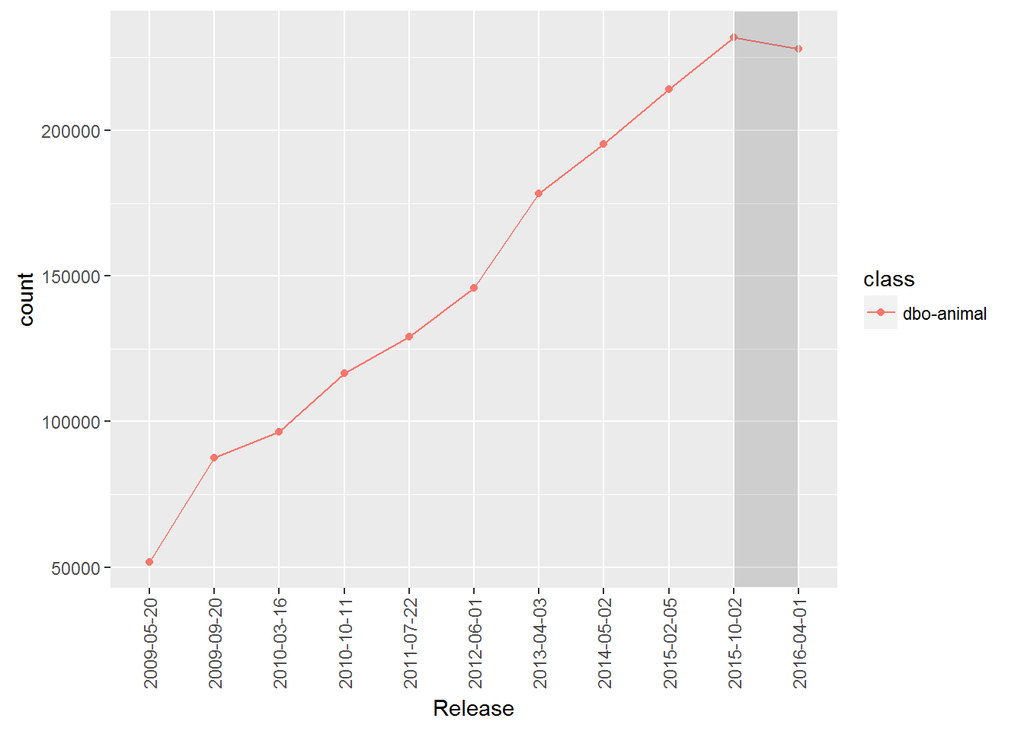

#### Historical Persitency

Historical Persistency Measure Result: Total no. of class = 10 and No. of persistency=1. HistPersistencyMeasure= 88.8888889 %

Releases with persistency values:

| version | Release | count | class | Persistency |
| --- | --- | --- | --- | --- |
| 3.3 | 2009-05-20 | 51809 | dbo-animal | 1 |
| 3.4 | 2009-09-20 | 87543 | dbo-animal | 1 |
| 3.5 | 2010-03-16 | 96534 | dbo-animal | 1 |
| 3.6 | 2010-10-11 | 116528 | dbo-animal | 1 |
| 3.7 | 2011-07-22 | 129027 | dbo-animal | 1 |
| 3.8 | 2012-06-01 | 145909 | dbo-animal | 1 |
| 3.9 | 2013-04-03 | 178289 | dbo-animal | 1 |
| 2014 | 2014-05-02 | 195176 | dbo-animal | 1 |
| 2015-04 | 2015-02-05 | 214106 | dbo-animal | 1 |
| 2015-10 | 2015-10-02 | 232019 | dbo-animal | 1 |
| 2016-04 | 2016-04-01 | 227963 | dbo-animal | 0 |

#### Consistency

No. of inconsistent property = 136

|  | property | v201604 | v201510 | v201502 |
| --- | --- | --- | --- | --- |
| 7 | http://dbpedia.org/ontology/Lake/areaOfCatchment | 0 | 1 | 0 |
| 8 | http://dbpedia.org/ontology/Lake/volume | 0 | 1 | 0 |
| 9 | http://dbpedia.org/ontology/MeanOfTransportation/length | 0 | 3 | 0 |
| 10 | http://dbpedia.org/ontology/Person/height | 0 | 1 | 0 |
| 11 | http://dbpedia.org/ontology/Person/weight | 0 | 1 | 0 |
| 13 | http://dbpedia.org/ontology/Weapon/weight | 0 | 1 | 0 |
| 14 | http://dbpedia.org/ontology/Work/runtime | 0 | 7 | 0 |
| 15 | http://dbpedia.org/ontology/abbreviation | 0 | 1 | 0 |
| 16 | http://dbpedia.org/ontology/activeYearsEndDate | 0 | 1 | 0 |
| 17 | http://dbpedia.org/ontology/activeYearsEndYear | 0 | 6 | 0 |
| 18 | http://dbpedia.org/ontology/activeYearsStartDate | 0 | 1 | 0 |
| 19 | http://dbpedia.org/ontology/activeYearsStartYear | 0 | 7 | 0 |
| 20 | http://dbpedia.org/ontology/address | 0 | 2 | 0 |
| 21 | http://dbpedia.org/ontology/album | 0 | 1 | 0 |
| 22 | http://dbpedia.org/ontology/alias | 0 | 14 | 1 |
| 23 | http://dbpedia.org/ontology/almaMater | 0 | 1 | 0 |
| 24 | http://dbpedia.org/ontology/areaOfCatchment | 0 | 1 | 0 |
| 25 | http://dbpedia.org/ontology/areaTotal | 0 | 3 | 0 |
| 26 | http://dbpedia.org/ontology/artist | 0 | 3 | 0 |
| 27 | http://dbpedia.org/ontology/author | 0 | 2 | 0 |
| 28 | http://dbpedia.org/ontology/background | 0 | 3 | 0 |
| 30 | http://dbpedia.org/ontology/beatifiedBy | 0 | 1 | 0 |
| 31 | http://dbpedia.org/ontology/binomial | 26 | 23 | 28 |
| 32 | http://dbpedia.org/ontology/birthDate | 0 | 55 | 18 |
| 33 | http://dbpedia.org/ontology/birthName | 0 | 5 | 1 |
| 34 | http://dbpedia.org/ontology/birthPlace | 0 | 37 | 8 |
| 35 | http://dbpedia.org/ontology/birthYear | 0 | 54 | 18 |
| 36 | http://dbpedia.org/ontology/builder | 0 | 5 | 0 |
| 37 | http://dbpedia.org/ontology/buildingEndDate | 0 | 1 | 0 |
| 39 | http://dbpedia.org/ontology/careerStation | 0 | 16 | 0 |

[output cut: 106 more lines]

List of Consistent Property over last two version:

| Property | version201604 | version201510 | version201504 |
| --- | --- | --- | --- |
| http://dbpedia.org/ontology/abstract | 96334 | 223983 | 207933 |
| http://dbpedia.org/ontology/award | 0 | 1996 | 1932 |
| http://dbpedia.org/ontology/binomialAuthority | 27348 | 62112 | 65795 |
| http://dbpedia.org/ontology/breeder | 0 | 1779 | 1569 |
| http://dbpedia.org/ontology/class | 103320 | 225020 | 241264 |
| http://dbpedia.org/ontology/color | 923 | 0 | 0 |
| http://dbpedia.org/ontology/colour | 0 | 3472 | 2798 |
| http://dbpedia.org/ontology/conservationStatus | 31115 | 34967 | 34946 |
| http://dbpedia.org/ontology/conservationStatusSystem | 29450 | 33943 | 33835 |
| http://dbpedia.org/ontology/country | 0 | 2612 | 2025 |
| http://dbpedia.org/ontology/dam | 0 | 450 | 369 |
| http://dbpedia.org/ontology/damsire | 0 | 2275 | 1727 |
| http://dbpedia.org/ontology/division | 148 | 344 | 536 |
| http://dbpedia.org/ontology/domain | 189 | 628 | 1113 |
| http://dbpedia.org/ontology/family | 150294 | 282704 | 339969 |
| http://dbpedia.org/ontology/foalDate | 0 | 1001 | 462 |
| http://dbpedia.org/ontology/genus | 53478 | 160738 | 158907 |
| http://dbpedia.org/ontology/grandsire | 0 | 2978 | 2274 |
| http://dbpedia.org/ontology/honours | 0 | 1061 | 919 |
| http://dbpedia.org/ontology/kingdom | 97311 | 216722 | 238095 |
| http://dbpedia.org/ontology/order | 108382 | 230716 | 239145 |
| http://dbpedia.org/ontology/owner | 0 | 2536 | 2178 |
| http://dbpedia.org/ontology/phylum | 103963 | 227055 | 257044 |
| http://dbpedia.org/ontology/race | 0 | 16292 | 14136 |
| http://dbpedia.org/ontology/sex | 0 | 3689 | 2753 |
| http://dbpedia.org/ontology/sire | 0 | 2832 | 2096 |
| http://dbpedia.org/ontology/soundRecording | 0 | 309 | 310 |
| http://dbpedia.org/ontology/species | 1100 | 1602 | 2182 |
| http://dbpedia.org/ontology/synonym | 28312 | 163964 | 155546 |
| http://dbpedia.org/ontology/thumbnail | 30409 | 67059 | 63339 |
| http://dbpedia.org/ontology/trainer | 0 | 3341 | 2687 |
| http://dbpedia.org/ontology/wikiPageExternalLink | 0 | 136613 | 134416 |
| http://dbpedia.org/ontology/wikiPageID | 0 | 224161 | 209966 |
| http://dbpedia.org/ontology/wikiPageLength | 0 | 224161 | 209966 |
| http://dbpedia.org/ontology/wikiPageOutDegree | 0 | 224161 | 209966 |
| http://dbpedia.org/ontology/wikiPageRevisionID | 0 | 224161 | 209966 |
| http://dbpedia.org/ontology/wikiPageWikiLink | 0 | 4965151 | 4604469 |
| http://dbpedia.org/ontology/wikiPageWikiLinkText | 0 | 308877 | 279460 |

#### Completeness

Total no. of property =174 No. of Consistent Property = 38 No. of incomplete property = 37

Percentage of completeness= 2.6315789 %

List of inincomplete property:

| property | Version201604 | Version201510 | NormFreqDiff |
| --- | --- | --- | --- |
| http://dbpedia.org/ontology/abstract | 0.4225861 | 0.9653649 | -0.5427788 |
| http://dbpedia.org/ontology/award | 0.0000000 | 0.0086027 | -0.0086027 |
| http://dbpedia.org/ontology/binomialAuthority | 0.1199668 | 0.2677022 | -0.1477354 |
| http://dbpedia.org/ontology/breeder | 0.0000000 | 0.0076675 | -0.0076675 |
| http://dbpedia.org/ontology/class | 0.4532314 | 0.9698344 | -0.5166029 |
| http://dbpedia.org/ontology/colour | 0.0000000 | 0.0149643 | -0.0149643 |
| http://dbpedia.org/ontology/conservationStatus | 0.1364914 | 0.1507075 | -0.0142160 |
| http://dbpedia.org/ontology/conservationStatusSystem | 0.1291876 | 0.1462941 | -0.0171064 |
| http://dbpedia.org/ontology/country | 0.0000000 | 0.0112577 | -0.0112577 |
| http://dbpedia.org/ontology/dam | 0.0000000 | 0.0019395 | -0.0019395 |
| http://dbpedia.org/ontology/damsire | 0.0000000 | 0.0098052 | -0.0098052 |
| http://dbpedia.org/ontology/division | 0.0006492 | 0.0014826 | -0.0008334 |
| http://dbpedia.org/ontology/domain | 0.0008291 | 0.0027067 | -0.0018776 |
| http://dbpedia.org/ontology/family | 0.6592912 | 1.2184519 | -0.5591607 |
| http://dbpedia.org/ontology/foalDate | 0.0000000 | 0.0043143 | -0.0043143 |
| http://dbpedia.org/ontology/genus | 0.2345907 | 0.6927795 | -0.4581888 |
| http://dbpedia.org/ontology/grandsire | 0.0000000 | 0.0128352 | -0.0128352 |
| http://dbpedia.org/ontology/honours | 0.0000000 | 0.0045729 | -0.0045729 |
| http://dbpedia.org/ontology/kingdom | 0.4268719 | 0.9340701 | -0.5071981 |
| http://dbpedia.org/ontology/order | 0.4754368 | 0.9943841 | -0.5189473 |
| http://dbpedia.org/ontology/owner | 0.0000000 | 0.0109301 | -0.0109301 |
| http://dbpedia.org/ontology/phylum | 0.4560521 | 0.9786052 | -0.5225531 |
| http://dbpedia.org/ontology/race | 0.0000000 | 0.0702184 | -0.0702184 |
| http://dbpedia.org/ontology/sex | 0.0000000 | 0.0158996 | -0.0158996 |
| http://dbpedia.org/ontology/sire | 0.0000000 | 0.0122059 | -0.0122059 |
| http://dbpedia.org/ontology/soundRecording | 0.0000000 | 0.0013318 | -0.0013318 |
| http://dbpedia.org/ontology/species | 0.0048253 | 0.0069046 | -0.0020793 |
| http://dbpedia.org/ontology/synonym | 0.1241956 | 0.7066835 | -0.5824879 |
| http://dbpedia.org/ontology/thumbnail | 0.1333945 | 0.2890237 | -0.1556293 |
| http://dbpedia.org/ontology/trainer | 0.0000000 | 0.0143997 | -0.0143997 |
| http://dbpedia.org/ontology/wikiPageExternalLink | 0.0000000 | 0.5888009 | -0.5888009 |
| http://dbpedia.org/ontology/wikiPageID | 0.0000000 | 0.9661321 | -0.9661321 |
| http://dbpedia.org/ontology/wikiPageLength | 0.0000000 | 0.9661321 | -0.9661321 |
| http://dbpedia.org/ontology/wikiPageOutDegree | 0.0000000 | 0.9661321 | -0.9661321 |
| http://dbpedia.org/ontology/wikiPageRevisionID | 0.0000000 | 0.9661321 | -0.9661321 |
| http://dbpedia.org/ontology/wikiPageWikiLink | 0.0000000 | 21.3997604 | -21.3997604 |
| http://dbpedia.org/ontology/wikiPageWikiLinkText | 0.0000000 | 1.3312574 | -1.3312574 |

#### KB growth

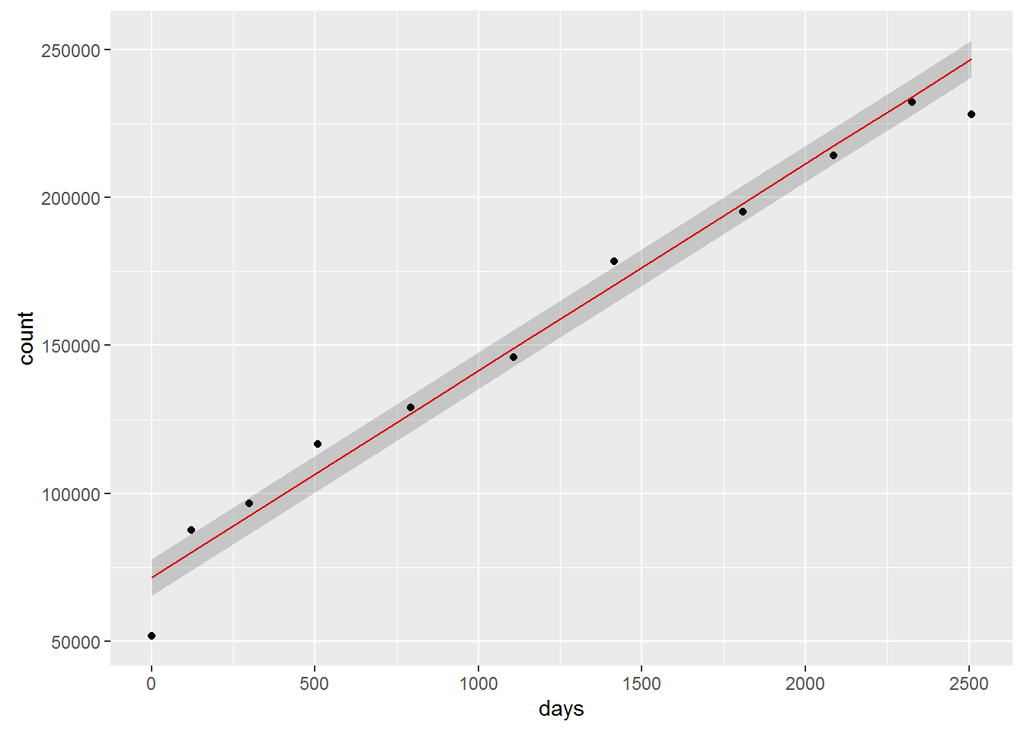

The normalized distance(ND)= 3.0526933

KB growth condition is 1 if ND<1 or KB growth is 0 if ND>=1

KB growth=0

### Class dbo Artist

[http://dbpedia.org/ontology/Artist]

Input: Set file location such as -

```r
location<- "/ExperimentalData/DBpedia/"
```

#### Persistency

Persistency Measure Result: 2016-04-01 value 145879 < 2015-10-02 value 184371. So Persistency= 0 Entity Count for 11 Release:

|  | version | Release | count | class |
| --- | --- | --- | --- | --- |
| 12 | 3.3 | 2009-05-20 | 65109 | dbo-artist |
| 13 | 3.4 | 2009-09-20 | 71789 | dbo-artist |
| 14 | 3.5 | 2010-03-16 | 73721 | dbo-artist |
| 15 | 3.6 | 2010-10-11 | 83847 | dbo-artist |
| 16 | 3.7 | 2011-07-22 | 57772 | dbo-artist |
| 17 | 3.8 | 2012-06-01 | 61073 | dbo-artist |
| 18 | 3.9 | 2013-04-03 | 93532 | dbo-artist |
| 19 | 2014 | 2014-05-02 | 96300 | dbo-artist |
| 20 | 2015-04 | 2015-02-05 | 175881 | dbo-artist |
| 21 | 2015-10 | 2015-10-02 | 184371 | dbo-artist |
| 22 | 2016-04 | 2016-04-01 | 145879 | dbo-artist |

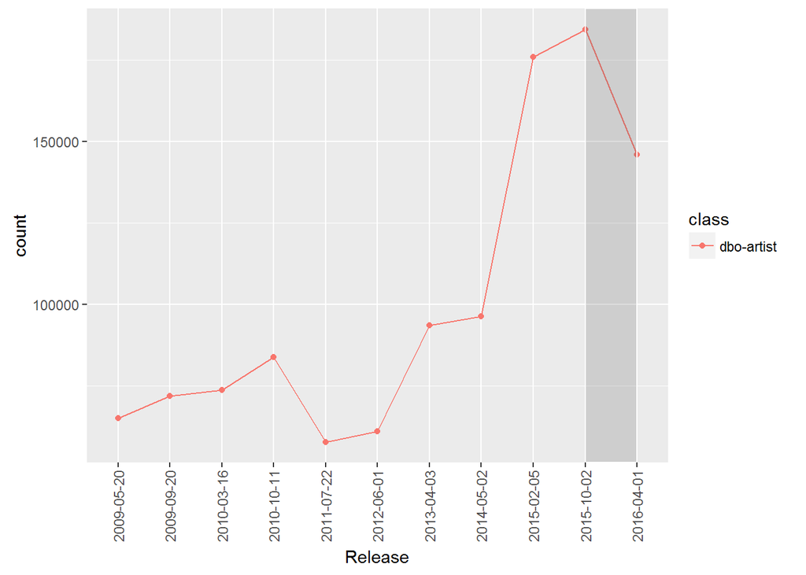

#### Historical Persitency

Historical Persistency Measure Result: Total no. of class = 10 and No. of persistency=2. HistPersistencyMeasure= 77.7777778 %

Releases with persistency values:

|  | version | Release | count | class | Persistency |
| --- | --- | --- | --- | --- | --- |
| 12 | 3.3 | 2009-05-20 | 65109 | dbo-artist | 1 |
| 13 | 3.4 | 2009-09-20 | 71789 | dbo-artist | 1 |
| 14 | 3.5 | 2010-03-16 | 73721 | dbo-artist | 1 |
| 15 | 3.6 | 2010-10-11 | 83847 | dbo-artist | 1 |
| 16 | 3.7 | 2011-07-22 | 57772 | dbo-artist | 0 |
| 17 | 3.8 | 2012-06-01 | 61073 | dbo-artist | 1 |
| 18 | 3.9 | 2013-04-03 | 93532 | dbo-artist | 1 |
| 19 | 2014 | 2014-05-02 | 96300 | dbo-artist | 1 |
| 20 | 2015-04 | 2015-02-05 | 175881 | dbo-artist | 1 |
| 21 | 2015-10 | 2015-10-02 | 184371 | dbo-artist | 1 |
| 22 | 2016-04 | 2016-04-01 | 145879 | dbo-artist | 0 |

#### Consistency

No. of inconsistent property = 348

|  | property | v201604 | v201510 | v201502 |
| --- | --- | --- | --- | --- |
| 15 | http://dbpedia.org/ontology/Astronaut/timeInSpace | 0 | 3 | 3 |
| 57 | http://dbpedia.org/ontology/Infrastructure/length | 0 | 2 | 2 |
| 94 | http://dbpedia.org/ontology/Planet/apoapsis | 0 | 1 | 1 |
| 95 | http://dbpedia.org/ontology/Planet/orbitalPeriod | 0 | 1 | 1 |
| 96 | http://dbpedia.org/ontology/Planet/periapsis | 0 | 1 | 1 |
| 97 | http://dbpedia.org/ontology/PopulatedPlace/areaTotal | 0 | 2 | 3 |
| 125 | http://dbpedia.org/ontology/Work/runtime | 0 | 96 | 0 |
| 132 | http://dbpedia.org/ontology/abbreviation | 0 | 4 | 3 |
| 133 | http://dbpedia.org/ontology/absoluteMagnitude | 0 | 1 | 1 |
| 134 | http://dbpedia.org/ontology/academicAdvisor | 0 | 2 | 2 |
| 136 | http://dbpedia.org/ontology/activeYearsEndDate | 0 | 29 | 83 |
| 137 | http://dbpedia.org/ontology/activeYearsStartDate | 0 | 37 | 0 |
| 138 | http://dbpedia.org/ontology/added | 0 | 30 | 29 |
| 139 | http://dbpedia.org/ontology/address | 0 | 2 | 12 |
| 140 | http://dbpedia.org/ontology/affiliation | 0 | 1 | 0 |
| 141 | http://dbpedia.org/ontology/afiAward | 39 | 0 | 0 |
| 144 | http://dbpedia.org/ontology/album | 0 | 2 | 8 |
| 145 | http://dbpedia.org/ontology/allegiance | 0 | 41 | 51 |
| 147 | http://dbpedia.org/ontology/americanComedyAward | 12 | 0 | 0 |
| 148 | http://dbpedia.org/ontology/animator | 0 | 0 | 26 |
| 149 | http://dbpedia.org/ontology/apoapsis | 0 | 1 | 1 |
| 150 | http://dbpedia.org/ontology/architect | 0 | 19 | 21 |
| 151 | http://dbpedia.org/ontology/architecturalStyle | 0 | 19 | 27 |
| 152 | http://dbpedia.org/ontology/area | 0 | 15 | 1 |
| 153 | http://dbpedia.org/ontology/areaCode | 0 | 0 | 2 |
| 154 | http://dbpedia.org/ontology/areaTotal | 0 | 3 | 3 |
| 155 | http://dbpedia.org/ontology/arielAward | 2 | 0 | 0 |
| 157 | http://dbpedia.org/ontology/artist | 0 | 54 | 0 |
| 158 | http://dbpedia.org/ontology/assets | 0 | 0 | 4 |
| 160 | http://dbpedia.org/ontology/associatedAct | 18 | 0 | 0 |

[output cut: 318 more lines]

List of Consistent Property over last two version:

| Property | version201604 | version201510 | version201504 |
| --- | --- | --- | --- |
| http://dbpedia.org/ontology/Person/height | 0 | 4002 | 3825 |
| http://dbpedia.org/ontology/Person/weight | 0 | 2495 | 107 |
| http://dbpedia.org/ontology/abstract | 73512 | 128580 | 159569 |
| http://dbpedia.org/ontology/academyAward | 412 | 0 | 0 |
| http://dbpedia.org/ontology/activeYearsEndYear | 10955 | 13915 | 15783 |
| http://dbpedia.org/ontology/activeYearsStartYear | 37518 | 43151 | 46126 |
| http://dbpedia.org/ontology/alias | 9543 | 24849 | 28035 |
| http://dbpedia.org/ontology/almaMater | 0 | 1092 | 6113 |
| http://dbpedia.org/ontology/associatedAct | 0 | 153 | 182 |
| http://dbpedia.org/ontology/associatedBand | 17000 | 89673 | 93044 |
| http://dbpedia.org/ontology/associatedMusicalArtist | 17000 | 89673 | 93044 |
| http://dbpedia.org/ontology/author | 0 | 124 | 0 |
| http://dbpedia.org/ontology/award | 3451 | 5281 | 9517 |
| http://dbpedia.org/ontology/background | 19074 | 49697 | 47479 |
| http://dbpedia.org/ontology/baftaAward | 234 | 0 | 0 |
| http://dbpedia.org/ontology/bandMember | 0 | 4431 | 5209 |
| http://dbpedia.org/ontology/battle | 0 | 143 | 169 |
| http://dbpedia.org/ontology/birthDate | 54589 | 106737 | 134639 |
| http://dbpedia.org/ontology/birthName | 3551 | 8051 | 12381 |
| http://dbpedia.org/ontology/birthPlace | 50766 | 122516 | 163306 |
| http://dbpedia.org/ontology/birthYear | 0 | 99309 | 130603 |
| http://dbpedia.org/ontology/careerStation | 0 | 137 | 162 |
| http://dbpedia.org/ontology/child | 190 | 603 | 1218 |
| http://dbpedia.org/ontology/citizenship | 182 | 113 | 908 |
| http://dbpedia.org/ontology/country | 0 | 8102 | 15402 |
| http://dbpedia.org/ontology/creator | 0 | 749 | 407 |
| http://dbpedia.org/ontology/deathCause | 0 | 240 | 297 |
| http://dbpedia.org/ontology/deathDate | 16033 | 42366 | 57647 |
| http://dbpedia.org/ontology/deathPlace | 12927 | 31172 | 45469 |
| http://dbpedia.org/ontology/deathYear | 0 | 40519 | 56114 |

[output cut: 64 more lines]

#### Completeness

Total no. of property =442 No. of Consistent Property = 94 No. of incomplete property = 81

Percentage of completeness= 13.8297872 %

List of inincomplete property:

| property | Version201604 | Version201510 | NormFreqDiff |
| --- | --- | --- | --- |
| http://dbpedia.org/ontology/Person/height | 0.0000000 | 0.0172486 | -0.0172486 |
| http://dbpedia.org/ontology/Person/weight | 0.0000000 | 0.0107534 | -0.0107534 |
| http://dbpedia.org/ontology/abstract | 0.3224734 | 0.5541788 | -0.2317054 |
| http://dbpedia.org/ontology/activeYearsEndYear | 0.0480560 | 0.0599735 | -0.0119175 |
| http://dbpedia.org/ontology/activeYearsStartYear | 0.1645793 | 0.1859805 | -0.0214011 |
| http://dbpedia.org/ontology/alias | 0.0418621 | 0.1070990 | -0.0652369 |
| http://dbpedia.org/ontology/almaMater | 0.0000000 | 0.0047065 | -0.0047065 |
| http://dbpedia.org/ontology/associatedAct | 0.0000000 | 0.0006594 | -0.0006594 |
| http://dbpedia.org/ontology/associatedBand | 0.0745735 | 0.3864899 | -0.3119164 |
| http://dbpedia.org/ontology/associatedMusicalArtist | 0.0745735 | 0.3864899 | -0.3119164 |
| http://dbpedia.org/ontology/author | 0.0000000 | 0.0005344 | -0.0005344 |
| http://dbpedia.org/ontology/award | 0.0151384 | 0.0227611 | -0.0076226 |
| http://dbpedia.org/ontology/background | 0.0836715 | 0.2141937 | -0.1305222 |
| http://dbpedia.org/ontology/bandMember | 0.0000000 | 0.0190976 | -0.0190976 |
| http://dbpedia.org/ontology/battle | 0.0000000 | 0.0006163 | -0.0006163 |
| http://dbpedia.org/ontology/birthDate | 0.2394643 | 0.4600356 | -0.2205713 |
| http://dbpedia.org/ontology/birthName | 0.0155771 | 0.0346997 | -0.0191227 |
| http://dbpedia.org/ontology/birthPlace | 0.2226940 | 0.5280430 | -0.3053489 |
| http://dbpedia.org/ontology/birthYear | 0.0000000 | 0.4280210 | -0.4280210 |
| http://dbpedia.org/ontology/careerStation | 0.0000000 | 0.0005905 | -0.0005905 |
| http://dbpedia.org/ontology/child | 0.0008335 | 0.0025989 | -0.0017655 |
| http://dbpedia.org/ontology/country | 0.0000000 | 0.0349196 | -0.0349196 |
| http://dbpedia.org/ontology/creator | 0.0000000 | 0.0032282 | -0.0032282 |
| http://dbpedia.org/ontology/deathCause | 0.0000000 | 0.0010344 | -0.0010344 |
| http://dbpedia.org/ontology/deathDate | 0.0703316 | 0.1825971 | -0.1122655 |
| http://dbpedia.org/ontology/deathPlace | 0.0567066 | 0.1343511 | -0.0776445 |
| http://dbpedia.org/ontology/deathYear | 0.0000000 | 0.1746366 | -0.1746366 |
| http://dbpedia.org/ontology/education | 0.0000000 | 0.0035170 | -0.0035170 |
| http://dbpedia.org/ontology/employer | 0.0000000 | 0.0008879 | -0.0008879 |
| http://dbpedia.org/ontology/field | 0.0126161 | 0.0523836 | -0.0397676 |

[output cut: 51 more lines]

#### KB growth

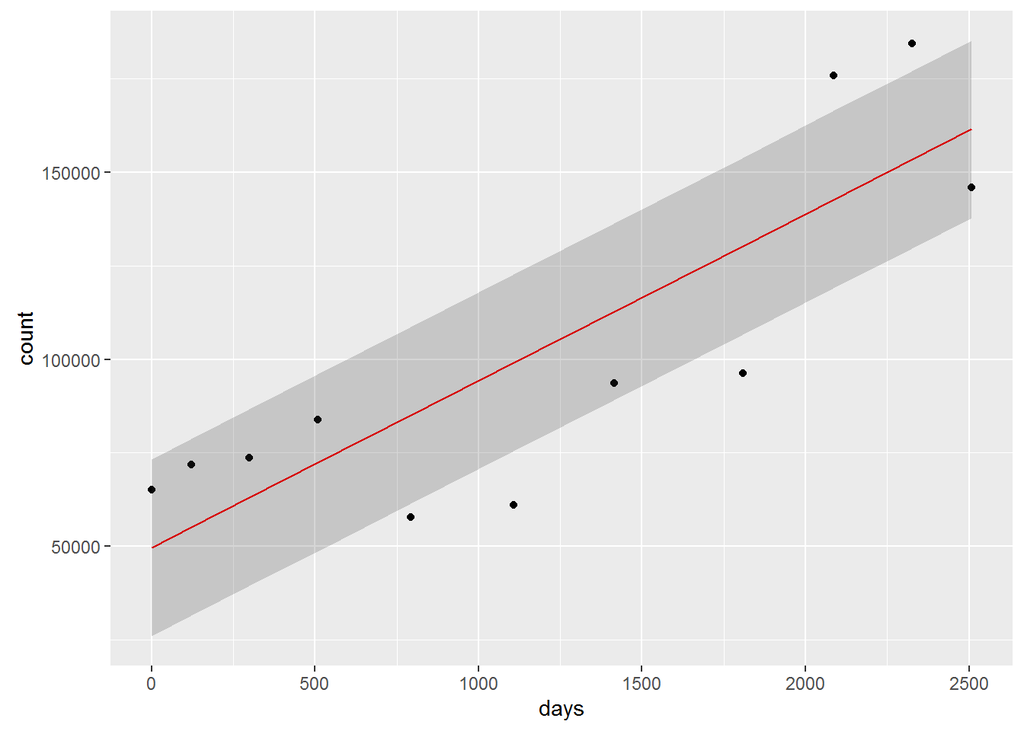

The normalized distance(ND)= 0.6604644

KB growth condition is 1 if ND<1 or KB growth is 0 if ND>=1

KB growth=1

### Class dbo Athlete

[http://dbpedia.org/ontology/Athlete]

Input: Set file location such as -

```r
location<- "/ExperimentalData/DBpedia/"
```

#### Persistency

Persistency Measure Result: 2016-04-01 value 371804 < 2015-10-02 value 434609. So Persistency= 0 Entity Count for 11 Release:

|  | version | Release | count | class |
| --- | --- | --- | --- | --- |
| 23 | 3.3 | 2009-05-20 | 95964 | dbo-athlete |
| 24 | 3.4 | 2009-09-20 | 113389 | dbo-athlete |
| 25 | 3.5 | 2010-03-16 | 73721 | dbo-athlete |
| 26 | 3.6 | 2010-10-11 | 133156 | dbo-athlete |
| 27 | 3.7 | 2011-07-22 | 150978 | dbo-athlete |
| 28 | 3.8 | 2012-06-01 | 185126 | dbo-athlete |
| 29 | 3.9 | 2013-04-03 | 313730 | dbo-athlete |
| 30 | 2014 | 2014-05-02 | 336091 | dbo-athlete |
| 31 | 2015-04 | 2015-02-05 | 335978 | dbo-athlete |
| 32 | 2015-10 | 2015-10-02 | 434609 | dbo-athlete |
| 33 | 2016-04 | 2016-04-01 | 371804 | dbo-athlete |

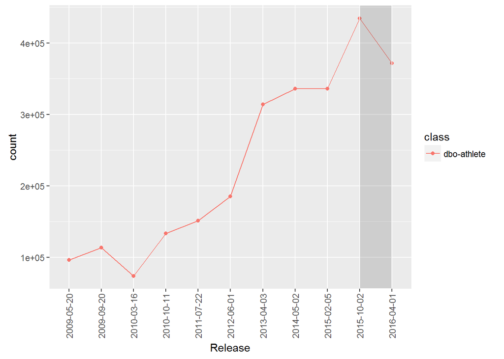

#### Historical Persitency

Historical Persistency Measure Result: Total no. of class = 10 and No. of persistency=3. HistPersistencyMeasure= 66.6666667 %

Releases with persistency values:

|  | version | Release | count | class | Persistency |
| --- | --- | --- | --- | --- | --- |
| 23 | 3.3 | 2009-05-20 | 95964 | dbo-athlete | 1 |
| 24 | 3.4 | 2009-09-20 | 113389 | dbo-athlete | 1 |
| 25 | 3.5 | 2010-03-16 | 73721 | dbo-athlete | 0 |
| 26 | 3.6 | 2010-10-11 | 133156 | dbo-athlete | 1 |
| 27 | 3.7 | 2011-07-22 | 150978 | dbo-athlete | 1 |
| 28 | 3.8 | 2012-06-01 | 185126 | dbo-athlete | 1 |
| 29 | 3.9 | 2013-04-03 | 313730 | dbo-athlete | 1 |
| 30 | 2014 | 2014-05-02 | 336091 | dbo-athlete | 1 |
| 31 | 2015-04 | 2015-02-05 | 335978 | dbo-athlete | 0 |
| 32 | 2015-10 | 2015-10-02 | 434609 | dbo-athlete | 1 |
| 33 | 2016-04 | 2016-04-01 | 371804 | dbo-athlete | 0 |

#### Consistency

No. of inconsistent property = 304

|  | property | v201604 | v201510 | v201502 |
| --- | --- | --- | --- | --- |
| 4 | http://dbpedia.org/ontology/Astronaut/timeInSpace | 0 | 1 | 3 |
| 5 | http://dbpedia.org/ontology/Automobile/wheelbase | 0 | 2 | 0 |
| 27 | http://dbpedia.org/ontology/MeanOfTransportation/height | 0 | 2 | 0 |
| 28 | http://dbpedia.org/ontology/MeanOfTransportation/length | 0 | 4 | 0 |
| 29 | http://dbpedia.org/ontology/MeanOfTransportation/weight | 0 | 1 | 0 |
| 30 | http://dbpedia.org/ontology/MeanOfTransportation/width | 0 | 2 | 0 |
| 58 | http://dbpedia.org/ontology/Software/fileSize | 0 | 13 | 13 |
| 63 | http://dbpedia.org/ontology/Weapon/weight | 0 | 1 | 0 |
| 70 | http://dbpedia.org/ontology/Work/runtime | 0 | 27 | 0 |
| 71 | http://dbpedia.org/ontology/added | 0 | 1 | 0 |
| 72 | http://dbpedia.org/ontology/affiliation | 0 | 2 | 0 |
| 73 | http://dbpedia.org/ontology/album | 0 | 2 | 0 |
| 74 | http://dbpedia.org/ontology/allegiance | 0 | 53 | 43 |
| 76 | http://dbpedia.org/ontology/appointer | 0 | 5 | 4 |
| 77 | http://dbpedia.org/ontology/architect | 0 | 1 | 0 |
| 78 | http://dbpedia.org/ontology/artist | 0 | 21 | 1 |
| 79 | http://dbpedia.org/ontology/assembly | 0 | 2 | 0 |
| 80 | http://dbpedia.org/ontology/assets | 0 | 1 | 1 |
| 81 | http://dbpedia.org/ontology/associate | 0 | 4 | 3 |
| 84 | http://dbpedia.org/ontology/author | 0 | 8 | 5 |
| 85 | http://dbpedia.org/ontology/bSide | 0 | 1 | 0 |
| 87 | http://dbpedia.org/ontology/bandMember | 0 | 3 | 4 |
| 88 | http://dbpedia.org/ontology/basedOn | 0 | 1 | 0 |
| 90 | http://dbpedia.org/ontology/binomialAuthority | 0 | 1 | 0 |
| 93 | http://dbpedia.org/ontology/bnfId | 0 | 1 | 7 |
| 94 | http://dbpedia.org/ontology/board | 0 | 11 | 14 |
| 96 | http://dbpedia.org/ontology/bodyStyle | 0 | 1 | 0 |
| 98 | http://dbpedia.org/ontology/broadcastStationClass | 0 | 1 | 0 |
| 99 | http://dbpedia.org/ontology/bronzeMedalist | 0 | 3 | 0 |
| 100 | http://dbpedia.org/ontology/budget | 0 | 1 | 0 |

[output cut: 274 more lines]

List of Consistent Property over last two version:

| property | v201604 | v201510 | v201504 |
| --- | --- | --- | --- |
| http://dbpedia.org/ontology/Person/height | 0 | 125941 | 83813 |
| http://dbpedia.org/ontology/Person/weight | 0 | 65175 | 32751 |
| http://dbpedia.org/ontology/abstract | 106908 | 349111 | 271338 |
| http://dbpedia.org/ontology/activeYearsEndDate | 8708 | 144 | 16308 |
| http://dbpedia.org/ontology/activeYearsEndYear | 56665 | 24072 | 24002 |
| http://dbpedia.org/ontology/activeYearsStartDate | 10716 | 140 | 18524 |
| http://dbpedia.org/ontology/activeYearsStartYear | 75621 | 38023 | 39234 |
| http://dbpedia.org/ontology/alias | 1424 | 33369 | 33182 |
| http://dbpedia.org/ontology/almaMater | 0 | 519 | 400 |
| http://dbpedia.org/ontology/associatedBand | 0 | 1477 | 1525 |
| http://dbpedia.org/ontology/associatedMusicalArtist | 0 | 1477 | 1525 |
| http://dbpedia.org/ontology/award | 2073 | 2499 | 5726 |
| http://dbpedia.org/ontology/background | 0 | 825 | 777 |
| http://dbpedia.org/ontology/battingSide | 0 | 643 | 19325 |
| http://dbpedia.org/ontology/battle | 0 | 168 | 140 |
| http://dbpedia.org/ontology/bestFinish | 0 | 319 | 212 |
| http://dbpedia.org/ontology/billed | 841 | 1997 | 2199 |
| http://dbpedia.org/ontology/birthDate | 93902 | 338933 | 315392 |
| http://dbpedia.org/ontology/birthName | 0 | 1595 | 498 |
| http://dbpedia.org/ontology/birthPlace | 120309 | 495617 | 482941 |
| http://dbpedia.org/ontology/birthYear | 0 | 307344 | 305194 |
| http://dbpedia.org/ontology/block | 0 | 133 | 0 |
| http://dbpedia.org/ontology/bowlRecord | 0 | 429 | 388 |
| http://dbpedia.org/ontology/careerPrizeMoney | 1221 | 3303 | 3536 |
| http://dbpedia.org/ontology/careerStation | 0 | 753794 | 731690 |
| http://dbpedia.org/ontology/centuryBreaks | 0 | 317 | 136 |
| http://dbpedia.org/ontology/championships | 699 | 789 | 808 |
| http://dbpedia.org/ontology/child | 0 | 140 | 103 |
| http://dbpedia.org/ontology/choreographer | 996 | 886 | 913 |
| http://dbpedia.org/ontology/club | 0 | 6206 | 5807 |

[output cut: 113 more lines]

#### Completeness

Total no. of property =447 No. of Consistent Property = 143 No. of incomplete property = 124

Percentage of completeness= 13.2867133 %

List of inincomplete property:

| property | Version201604 | Version201510 | NormFreqDiff |
| --- | --- | --- | --- |
| http://dbpedia.org/ontology/Person/height | 0.0000000 | 0.2897800 | -0.2897800 |
| http://dbpedia.org/ontology/Person/weight | 0.0000000 | 0.1499624 | -0.1499624 |
| http://dbpedia.org/ontology/abstract | 0.2875386 | 0.8032760 | -0.5157375 |
| http://dbpedia.org/ontology/alias | 0.0038300 | 0.0767794 | -0.0729494 |
| http://dbpedia.org/ontology/almaMater | 0.0000000 | 0.0011942 | -0.0011942 |
| http://dbpedia.org/ontology/associatedBand | 0.0000000 | 0.0033985 | -0.0033985 |
| http://dbpedia.org/ontology/associatedMusicalArtist | 0.0000000 | 0.0033985 | -0.0033985 |
| http://dbpedia.org/ontology/award | 0.0055755 | 0.0057500 | -0.0001745 |
| http://dbpedia.org/ontology/background | 0.0000000 | 0.0018983 | -0.0018983 |
| http://dbpedia.org/ontology/battingSide | 0.0000000 | 0.0014795 | -0.0014795 |
| http://dbpedia.org/ontology/battle | 0.0000000 | 0.0003866 | -0.0003866 |
| http://dbpedia.org/ontology/bestFinish | 0.0000000 | 0.0007340 | -0.0007340 |
| http://dbpedia.org/ontology/billed | 0.0022619 | 0.0045949 | -0.0023330 |
| http://dbpedia.org/ontology/birthDate | 0.2525578 | 0.7798573 | -0.5272995 |
| http://dbpedia.org/ontology/birthName | 0.0000000 | 0.0036700 | -0.0036700 |
| http://dbpedia.org/ontology/birthPlace | 0.3235818 | 1.1403745 | -0.8167927 |
| http://dbpedia.org/ontology/birthYear | 0.0000000 | 0.7071736 | -0.7071736 |
| http://dbpedia.org/ontology/block | 0.0000000 | 0.0003060 | -0.0003060 |
| http://dbpedia.org/ontology/bowlRecord | 0.0000000 | 0.0009871 | -0.0009871 |
| http://dbpedia.org/ontology/careerPrizeMoney | 0.0032840 | 0.0075999 | -0.0043159 |
| http://dbpedia.org/ontology/careerStation | 0.0000000 | 1.7344188 | -1.7344188 |
| http://dbpedia.org/ontology/centuryBreaks | 0.0000000 | 0.0007294 | -0.0007294 |
| http://dbpedia.org/ontology/child | 0.0000000 | 0.0003221 | -0.0003221 |
| http://dbpedia.org/ontology/club | 0.0000000 | 0.0142795 | -0.0142795 |
| http://dbpedia.org/ontology/coach | 0.0034346 | 0.0037505 | -0.0003159 |
| http://dbpedia.org/ontology/college | 0.0229234 | 0.0301121 | -0.0071888 |
| http://dbpedia.org/ontology/computingPlatform | 0.0000000 | 0.0012724 | -0.0012724 |
| http://dbpedia.org/ontology/country | 0.0004680 | 0.0510689 | -0.0506009 |
| http://dbpedia.org/ontology/currentPartner | 0.0012964 | 0.0013368 | -0.0000405 |
| http://dbpedia.org/ontology/currentRecord | 0.0000000 | 0.0004763 | -0.0004763 |

[output cut: 94 more lines]

#### KB growth

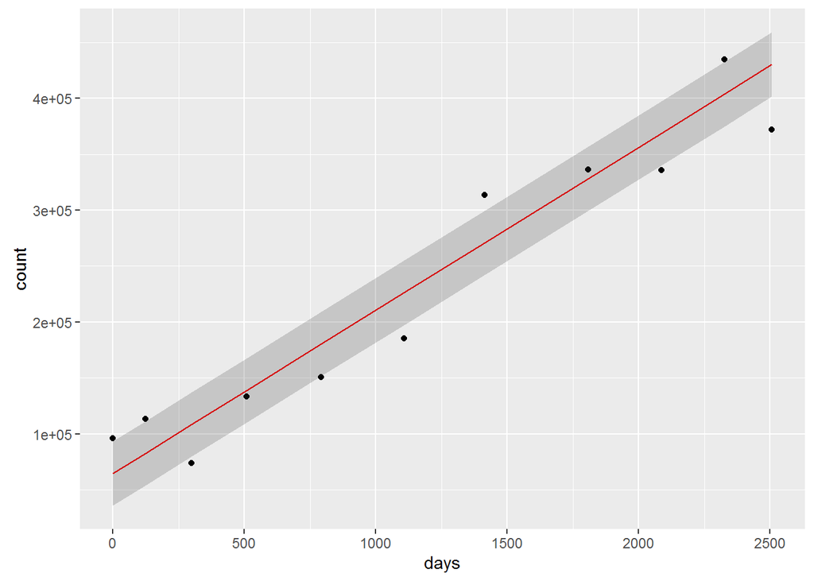

The normalized distance(ND)= 2.0316388

KB growth condition is 1 if ND<1 or KB growth is 0 if ND>=1

KB growth=0

### Class dbo Film

[http://dbpedia.org/ontology/Film]

Input: Set file location such as -

```r
location<- "/ExperimentalData/DBpedia/"
```

#### Persistency

Persistency Measure Result: 2016-04-01 value 146449 < 2015-10-02 value 177989. So Persistency= 0 Entity Count for 11 Release:

|  | version | Release | count | class |
| --- | --- | --- | --- | --- |
| 34 | 3.3 | 2009-05-20 | 40310 | dbo-film |
| 35 | 3.4 | 2009-09-20 | 44706 | dbo-film |
| 36 | 3.5 | 2010-03-16 | 49182 | dbo-film |
| 37 | 3.6 | 2010-10-11 | 53619 | dbo-film |
| 38 | 3.7 | 2011-07-22 | 60194 | dbo-film |
| 39 | 3.8 | 2012-06-01 | 71715 | dbo-film |
| 40 | 3.9 | 2013-04-03 | 77794 | dbo-film |
| 41 | 2014 | 2014-05-02 | 87285 | dbo-film |
| 42 | 2015-04 | 2015-02-05 | 171272 | dbo-film |
| 43 | 2015-10 | 2015-10-02 | 177989 | dbo-film |
| 44 | 2016-04 | 2016-04-01 | 146449 | dbo-film |

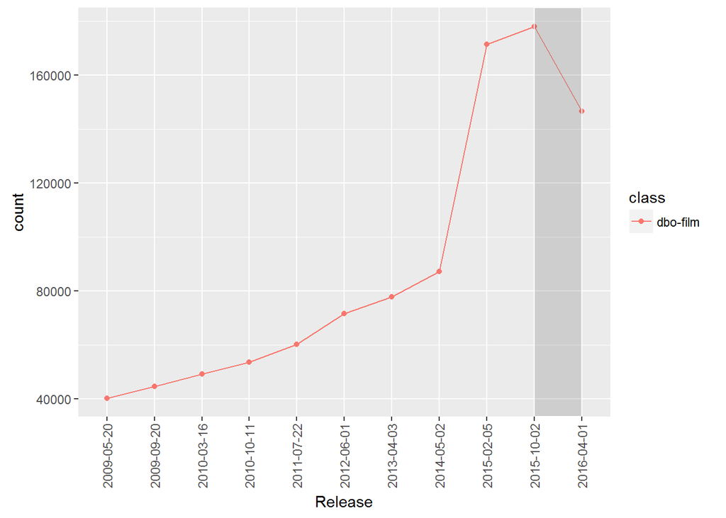

#### Historical Persitency

Historical Persistency Measure Result: Total no. of class = 10 and No. of persistency=1. HistPersistencyMeasure= 88.8888889 %

Releases with persistency values:

|  | version | Release | count | class | Persistency |
| --- | --- | --- | --- | --- | --- |
| 34 | 3.3 | 2009-05-20 | 40310 | dbo-film | 1 |
| 35 | 3.4 | 2009-09-20 | 44706 | dbo-film | 1 |
| 36 | 3.5 | 2010-03-16 | 49182 | dbo-film | 1 |
| 37 | 3.6 | 2010-10-11 | 53619 | dbo-film | 1 |
| 38 | 3.7 | 2011-07-22 | 60194 | dbo-film | 1 |
| 39 | 3.8 | 2012-06-01 | 71715 | dbo-film | 1 |
| 40 | 3.9 | 2013-04-03 | 77794 | dbo-film | 1 |
| 41 | 2014 | 2014-05-02 | 87285 | dbo-film | 1 |
| 42 | 2015-04 | 2015-02-05 | 171272 | dbo-film | 1 |
| 43 | 2015-10 | 2015-10-02 | 177989 | dbo-film | 1 |
| 44 | 2016-04 | 2016-04-01 | 146449 | dbo-film | 0 |

#### Consistency

No. of inconsistent property = 389

|  | property | v201604 | v201510 | v201502 |
| --- | --- | --- | --- | --- |
| 5 | http://dbpedia.org/ontology/Automobile/wheelbase | 0 | 9 | 0 |
| 23 | http://dbpedia.org/ontology/Infrastructure/length | 0 | 1 | 0 |
| 24 | http://dbpedia.org/ontology/Lake/areaOfCatchment | 0 | 1 | 0 |
| 25 | http://dbpedia.org/ontology/Lake/shoreLength | 0 | 1 | 1 |
| 26 | http://dbpedia.org/ontology/Lake/volume | 0 | 1 | 1 |
| 28 | http://dbpedia.org/ontology/MeanOfTransportation/height | 0 | 9 | 0 |
| 29 | http://dbpedia.org/ontology/MeanOfTransportation/length | 0 | 11 | 0 |
| 30 | http://dbpedia.org/ontology/MeanOfTransportation/weight | 0 | 4 | 0 |
| 31 | http://dbpedia.org/ontology/MeanOfTransportation/width | 0 | 9 | 0 |
| 42 | http://dbpedia.org/ontology/Person/height | 0 | 83 | 49 |
| 46 | http://dbpedia.org/ontology/Person/weight | 0 | 14 | 8 |
| 49 | http://dbpedia.org/ontology/PopulatedPlace/areaTotal | 0 | 2 | 2 |
| 77 | http://dbpedia.org/ontology/Weapon/height | 0 | 2 | 0 |
| 78 | http://dbpedia.org/ontology/Weapon/length | 0 | 9 | 0 |
| 79 | http://dbpedia.org/ontology/Weapon/weight | 0 | 9 | 0 |
| 80 | http://dbpedia.org/ontology/Weapon/width | 0 | 2 | 0 |
| 87 | http://dbpedia.org/ontology/aSide | 0 | 3 | 4 |
| 88 | http://dbpedia.org/ontology/abbreviation | 0 | 1 | 1 |
| 91 | http://dbpedia.org/ontology/activeYearsEndDate | 0 | 1 | 7 |
| 92 | http://dbpedia.org/ontology/activeYearsStartDate | 0 | 1 | 7 |
| 93 | http://dbpedia.org/ontology/added | 0 | 12 | 9 |
| 94 | http://dbpedia.org/ontology/address | 0 | 31 | 19 |
| 95 | http://dbpedia.org/ontology/affiliation | 0 | 5 | 3 |
| 97 | http://dbpedia.org/ontology/album | 0 | 58 | 63 |
| 98 | http://dbpedia.org/ontology/allegiance | 0 | 3 | 3 |
| 101 | http://dbpedia.org/ontology/architect | 0 | 5 | 6 |
| 103 | http://dbpedia.org/ontology/architecturalStyle | 0 | 4 | 4 |
| 104 | http://dbpedia.org/ontology/area | 0 | 5 | 0 |
| 105 | http://dbpedia.org/ontology/areaCode | 0 | 1 | 1 |
| 107 | http://dbpedia.org/ontology/areaOfCatchment | 0 | 1 | 0 |

[output cut: 359 more lines]

List of Consistent Property over last two version:

| Property | version201604 | version201510 | version201504 |
| --- | --- | --- | --- |
| http://dbpedia.org/ontology/Work/runtime | 36815 | 78838 | 65703 |
| http://dbpedia.org/ontology/abstract | 46862 | 128899 | 121964 |
| http://dbpedia.org/ontology/activeYearsEndYear | 0 | 1726 | 1605 |
| http://dbpedia.org/ontology/activeYearsStartYear | 0 | 3424 | 3202 |
| http://dbpedia.org/ontology/alias | 0 | 1686 | 1637 |
| http://dbpedia.org/ontology/almaMater | 0 | 412 | 414 |
| http://dbpedia.org/ontology/amgid | 1344 | 0 | 0 |
| http://dbpedia.org/ontology/animator | 0 | 3019 | 3053 |
| http://dbpedia.org/ontology/artist | 0 | 1209 | 1148 |
| http://dbpedia.org/ontology/author | 0 | 4017 | 2432 |
| http://dbpedia.org/ontology/award | 0 | 473 | 469 |
| http://dbpedia.org/ontology/basedOn | 0 | 2782 | 2424 |
| http://dbpedia.org/ontology/birthDate | 0 | 5763 | 5553 |
| http://dbpedia.org/ontology/birthName | 0 | 1910 | 1840 |
| http://dbpedia.org/ontology/birthPlace | 0 | 9961 | 10197 |
| http://dbpedia.org/ontology/birthYear | 0 | 5657 | 5507 |
| http://dbpedia.org/ontology/budget | 6156 | 13841 | 12491 |
| http://dbpedia.org/ontology/channel | 0 | 699 | 609 |
| http://dbpedia.org/ontology/characterInPlay | 0 | 677 | 652 |
| http://dbpedia.org/ontology/child | 0 | 275 | 251 |
| http://dbpedia.org/ontology/cinematography | 18363 | 39831 | 37467 |
| http://dbpedia.org/ontology/company | 0 | 1620 | 672 |
| http://dbpedia.org/ontology/completionDate | 0 | 810 | 553 |
| http://dbpedia.org/ontology/composer | 0 | 1522 | 383 |
| http://dbpedia.org/ontology/computingPlatform | 0 | 220 | 189 |
| http://dbpedia.org/ontology/country | 15133 | 26025 | 24174 |
| http://dbpedia.org/ontology/creator | 0 | 1123 | 731 |
| http://dbpedia.org/ontology/dcc | 0 | 206 | 192 |
| http://dbpedia.org/ontology/deathCause | 0 | 313 | 369 |
| http://dbpedia.org/ontology/deathDate | 0 | 2411 | 2299 |

[output cut: 89 more lines]

#### Completeness

Total no. of property =508 No. of Consistent Property = 119 No. of incomplete property = 114

Percentage of completeness= 4.2016807 %

List of inincomplete property:

| property | Version201604 | Version201510 | NormFreqDiff |
| --- | --- | --- | --- |
| http://dbpedia.org/ontology/Work/runtime | 0.1614955 | 0.3397911 | -0.1782956 |
| http://dbpedia.org/ontology/abstract | 0.2055684 | 0.5555536 | -0.3499852 |
| http://dbpedia.org/ontology/activeYearsEndYear | 0.0000000 | 0.0074390 | -0.0074390 |
| http://dbpedia.org/ontology/activeYearsStartYear | 0.0000000 | 0.0147574 | -0.0147574 |
| http://dbpedia.org/ontology/alias | 0.0000000 | 0.0072666 | -0.0072666 |
| http://dbpedia.org/ontology/almaMater | 0.0000000 | 0.0017757 | -0.0017757 |
| http://dbpedia.org/ontology/animator | 0.0000000 | 0.0130119 | -0.0130119 |
| http://dbpedia.org/ontology/artist | 0.0000000 | 0.0052108 | -0.0052108 |
| http://dbpedia.org/ontology/author | 0.0000000 | 0.0173132 | -0.0173132 |
| http://dbpedia.org/ontology/award | 0.0000000 | 0.0020386 | -0.0020386 |
| http://dbpedia.org/ontology/basedOn | 0.0000000 | 0.0119904 | -0.0119904 |
| http://dbpedia.org/ontology/birthDate | 0.0000000 | 0.0248385 | -0.0248385 |
| http://dbpedia.org/ontology/birthName | 0.0000000 | 0.0082321 | -0.0082321 |
| http://dbpedia.org/ontology/birthPlace | 0.0000000 | 0.0429318 | -0.0429318 |
| http://dbpedia.org/ontology/birthYear | 0.0000000 | 0.0243816 | -0.0243816 |
| http://dbpedia.org/ontology/budget | 0.0270044 | 0.0596546 | -0.0326502 |
| http://dbpedia.org/ontology/channel | 0.0000000 | 0.0030127 | -0.0030127 |
| http://dbpedia.org/ontology/characterInPlay | 0.0000000 | 0.0029179 | -0.0029179 |
| http://dbpedia.org/ontology/child | 0.0000000 | 0.0011852 | -0.0011852 |
| http://dbpedia.org/ontology/cinematography | 0.0805525 | 0.1716713 | -0.0911187 |
| http://dbpedia.org/ontology/company | 0.0000000 | 0.0069822 | -0.0069822 |
| http://dbpedia.org/ontology/completionDate | 0.0000000 | 0.0034911 | -0.0034911 |
| http://dbpedia.org/ontology/composer | 0.0000000 | 0.0065598 | -0.0065598 |
| http://dbpedia.org/ontology/computingPlatform | 0.0000000 | 0.0009482 | -0.0009482 |
| http://dbpedia.org/ontology/country | 0.0663836 | 0.1121675 | -0.0457840 |
| http://dbpedia.org/ontology/creator | 0.0000000 | 0.0048401 | -0.0048401 |
| http://dbpedia.org/ontology/dcc | 0.0000000 | 0.0008879 | -0.0008879 |
| http://dbpedia.org/ontology/deathCause | 0.0000000 | 0.0013490 | -0.0013490 |
| http://dbpedia.org/ontology/deathDate | 0.0000000 | 0.0103914 | -0.0103914 |
| http://dbpedia.org/ontology/deathPlace | 0.0000000 | 0.0156108 | -0.0156108 |

[output cut: 84 more lines]

#### KB growth

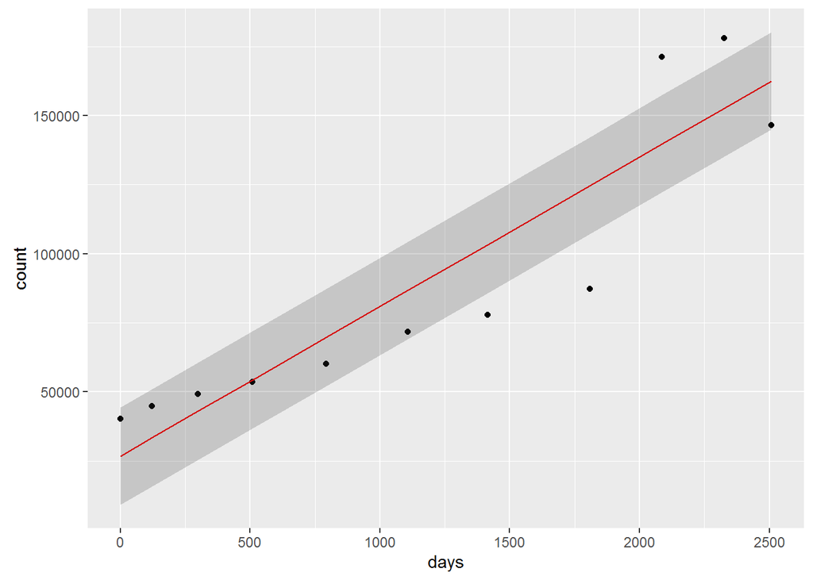

The normalized distance(ND)= 0.9129531

KB growth condition is 1 if ND<1 or KB growth is 0 if ND>=1

KB growth=1

### Class dbo MusicalWork

[http://dbpedia.org/ontology/MusicalWork]

Input: Set file location such as -

```r
location<- "/ExperimentalData/DBpedia/"
```

#### Persistency

Persistency Measure Result: 2016-04-01 value 203392 < 2015-10-02 value 213785. So Persistency= 0 Entity Count for 11 Release:

|  | version | Release | count | class |
| --- | --- | --- | --- | --- |
| 45 | 3.3 | 2009-05-20 | 113329 | dbo-musicalWork |
| 46 | 3.4 | 2009-09-20 | 120068 | dbo-musicalWork |
| 47 | 3.5 | 2010-03-16 | 131040 | dbo-musicalWork |
| 48 | 3.6 | 2010-10-11 | 138921 | dbo-musicalWork |
| 49 | 3.7 | 2011-07-22 | 110515 | dbo-musicalWork |
| 50 | 3.8 | 2012-06-01 | 159071 | dbo-musicalWork |
| 51 | 3.9 | 2013-04-03 | 198516 | dbo-musicalWork |
| 52 | 2014 | 2014-05-02 | 193205 | dbo-musicalWork |
| 53 | 2015-04 | 2015-02-05 | 163958 | dbo-musicalWork |
| 54 | 2015-10 | 2015-10-02 | 213785 | dbo-musicalWork |
| 55 | 2016-04 | 2016-04-01 | 203392 | dbo-musicalWork |

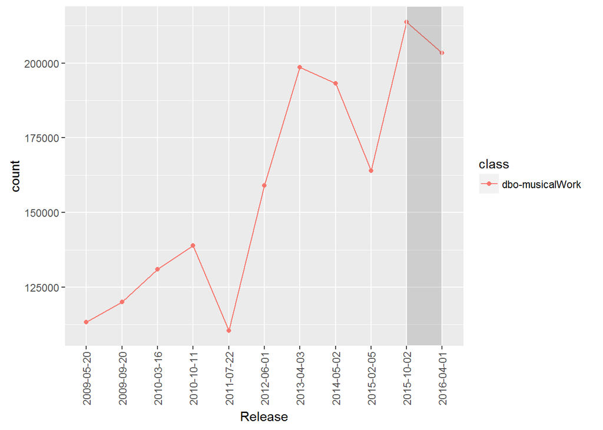

#### Historical Persitency

Historical Persistency Measure Result: Total no. of class = 10 and No. of persistency=4. HistPersistencyMeasure= 55.5555556 %

Releases with persistency values:

|  | version | Release | count | class | Persistency |
| --- | --- | --- | --- | --- | --- |
| 45 | 3.3 | 2009-05-20 | 113329 | dbo-musicalWork | 1 |
| 46 | 3.4 | 2009-09-20 | 120068 | dbo-musicalWork | 1 |
| 47 | 3.5 | 2010-03-16 | 131040 | dbo-musicalWork | 1 |
| 48 | 3.6 | 2010-10-11 | 138921 | dbo-musicalWork | 1 |
| 49 | 3.7 | 2011-07-22 | 110515 | dbo-musicalWork | 0 |
| 50 | 3.8 | 2012-06-01 | 159071 | dbo-musicalWork | 1 |
| 51 | 3.9 | 2013-04-03 | 198516 | dbo-musicalWork | 1 |
| 52 | 2014 | 2014-05-02 | 193205 | dbo-musicalWork | 0 |
| 53 | 2015-04 | 2015-02-05 | 163958 | dbo-musicalWork | 0 |
| 54 | 2015-10 | 2015-10-02 | 213785 | dbo-musicalWork | 1 |
| 55 | 2016-04 | 2016-04-01 | 203392 | dbo-musicalWork | 0 |

#### Consistency

No. of inconsistent property = 297

|  | property | v201604 | v201510 | v201502 |
| --- | --- | --- | --- | --- |
| 12 | http://dbpedia.org/ontology/Infrastructure/length | 0 | 2 | 0 |
| 13 | http://dbpedia.org/ontology/Lake/shoreLength | 0 | 1 | 0 |
| 14 | http://dbpedia.org/ontology/Lake/volume | 0 | 1 | 0 |
| 15 | http://dbpedia.org/ontology/MeanOfTransportation/height | 0 | 3 | 0 |
| 16 | http://dbpedia.org/ontology/MeanOfTransportation/length | 0 | 10 | 0 |
| 17 | http://dbpedia.org/ontology/MeanOfTransportation/weight | 0 | 1 | 0 |
| 18 | http://dbpedia.org/ontology/MeanOfTransportation/width | 0 | 4 | 0 |
| 29 | http://dbpedia.org/ontology/Person/height | 0 | 1 | 0 |
| 35 | http://dbpedia.org/ontology/PopulatedPlace/areaTotal | 0 | 5 | 0 |
| 36 | http://dbpedia.org/ontology/PopulatedPlace/populationDensity | 0 | 2 | 0 |
| 41 | http://dbpedia.org/ontology/Software/fileSize | 0 | 2 | 0 |
| 42 | http://dbpedia.org/ontology/Stream/discharge | 0 | 1 | 0 |
| 43 | http://dbpedia.org/ontology/Stream/maximumDischarge | 0 | 1 | 0 |
| 44 | http://dbpedia.org/ontology/Stream/minimumDischarge | 0 | 1 | 0 |
| 69 | http://dbpedia.org/ontology/Weapon/diameter | 0 | 3 | 0 |
| 70 | http://dbpedia.org/ontology/Weapon/height | 0 | 7 | 0 |
| 71 | http://dbpedia.org/ontology/Weapon/length | 0 | 18 | 0 |
| 72 | http://dbpedia.org/ontology/Weapon/weight | 0 | 29 | 0 |
| 73 | http://dbpedia.org/ontology/Weapon/width | 0 | 7 | 0 |
| 79 | http://dbpedia.org/ontology/abbreviation | 0 | 2 | 0 |
| 80 | http://dbpedia.org/ontology/acquirementDate | 0 | 1 | 0 |
| 82 | http://dbpedia.org/ontology/activeYearsEndDate | 0 | 2 | 0 |
| 83 | http://dbpedia.org/ontology/activeYearsEndYear | 0 | 25 | 4 |
| 84 | http://dbpedia.org/ontology/activeYearsStartDate | 0 | 2 | 0 |
| 85 | http://dbpedia.org/ontology/activeYearsStartYear | 0 | 40 | 8 |
| 86 | http://dbpedia.org/ontology/added | 0 | 1 | 0 |
| 87 | http://dbpedia.org/ontology/address | 0 | 1 | 0 |
| 88 | http://dbpedia.org/ontology/affiliation | 0 | 2 | 0 |
| 89 | http://dbpedia.org/ontology/alias | 0 | 9 | 2 |
| 90 | http://dbpedia.org/ontology/almaMater | 0 | 3 | 0 |

[output cut: 267 more lines]

List of Consistent Property over last two Releases:

| Property | version201604 | version201510 | version201504 |
| --- | --- | --- | --- |
| http://dbpedia.org/ontology/Work/runtime | 89887 | 149194 | 112620 |
| http://dbpedia.org/ontology/aSide | 1599 | 2889 | 4011 |
| http://dbpedia.org/ontology/abstract | 120892 | 191915 | 146089 |
| http://dbpedia.org/ontology/album | 10301 | 45870 | 41080 |
| http://dbpedia.org/ontology/artist | 89778 | 139914 | 105328 |
| http://dbpedia.org/ontology/author | 0 | 1505 | 0 |
| http://dbpedia.org/ontology/award | 0 | 381 | 0 |
| http://dbpedia.org/ontology/bSide | 12072 | 23129 | 31907 |
| http://dbpedia.org/ontology/basedOn | 0 | 880 | 0 |
| http://dbpedia.org/ontology/certification | 2591 | 3221 | 2754 |
| http://dbpedia.org/ontology/compiler | 166 | 289 | 250 |
| http://dbpedia.org/ontology/composer | 421 | 1320 | 1199 |
| http://dbpedia.org/ontology/director | 182 | 473 | 321 |
| http://dbpedia.org/ontology/format | 25421 | 54038 | 57269 |
| http://dbpedia.org/ontology/genre | 133041 | 291289 | 245980 |
| http://dbpedia.org/ontology/guest | 0 | 132 | 0 |
| http://dbpedia.org/ontology/imdbId | 0 | 211 | 0 |
| http://dbpedia.org/ontology/language | 1733 | 5767 | 5393 |
| http://dbpedia.org/ontology/longtype | 988 | 1730 | 1392 |
| http://dbpedia.org/ontology/lyrics | 0 | 1797 | 120 |
| http://dbpedia.org/ontology/musicBy | 0 | 1404 | 0 |
| http://dbpedia.org/ontology/musicalArtist | 32325 | 53343 | 45690 |
| http://dbpedia.org/ontology/musicalBand | 32325 | 53343 | 45690 |
| http://dbpedia.org/ontology/picture | 0 | 660 | 512 |
| http://dbpedia.org/ontology/previousWork | 89279 | 130712 | 105074 |
| http://dbpedia.org/ontology/producer | 65975 | 160058 | 135660 |
| http://dbpedia.org/ontology/recordDate | 7292 | 15081 | 10732 |
| http://dbpedia.org/ontology/recordLabel | 110224 | 182733 | 155007 |
| http://dbpedia.org/ontology/recordPlace | 21898 | 0 | 0 |
| http://dbpedia.org/ontology/recordedIn | 0 | 53819 | 51184 |
| http://dbpedia.org/ontology/releaseDate | 67711 | 122547 | 93809 |
| http://dbpedia.org/ontology/review | 86420 | 0 | 0 |
| http://dbpedia.org/ontology/runtime | 89887 | 149194 | 112633 |
| http://dbpedia.org/ontology/soundRecording | 0 | 6256 | 5618 |
| http://dbpedia.org/ontology/subsequentWork | 89642 | 131702 | 105426 |
| http://dbpedia.org/ontology/subtitle | 0 | 131 | 0 |
| http://dbpedia.org/ontology/thumbnail | 58200 | 9361 | 6668 |
| http://dbpedia.org/ontology/trackNumber | 2074 | 2693 | 2587 |
| http://dbpedia.org/ontology/type | 38668 | 41880 | 31131 |
| http://dbpedia.org/ontology/wikiPageExternalLink | 0 | 107889 | 83616 |
| http://dbpedia.org/ontology/wikiPageID | 0 | 193848 | 151913 |
| http://dbpedia.org/ontology/wikiPageLength | 0 | 193848 | 151913 |
| http://dbpedia.org/ontology/wikiPageOutDegree | 0 | 193848 | 151913 |
| http://dbpedia.org/ontology/wikiPageRevisionID | 0 | 193848 | 151913 |
| http://dbpedia.org/ontology/wikiPageWikiLink | 0 | 6566262 | 5387903 |
| http://dbpedia.org/ontology/wikiPageWikiLinkText | 0 | 385066 | 295454 |
| http://dbpedia.org/ontology/writer | 21973 | 64184 | 57337 |

#### Completeness

Total no. of property =344 No. of Consistent Property = 47 No. of incomplete property = 44

Percentage of completeness= 6.3829787 %

List of inincomplete property:

| property | Version201604 | Version201510 | NormFreqDiff |
| --- | --- | --- | --- |
| http://dbpedia.org/ontology/Work/runtime | 0.3943052 | 0.6430249 | -0.2487197 |
| http://dbpedia.org/ontology/aSide | 0.0070143 | 0.0124516 | -0.0054373 |
| http://dbpedia.org/ontology/abstract | 0.5303141 | 0.8271521 | -0.2968380 |
| http://dbpedia.org/ontology/album | 0.0451872 | 0.1976993 | -0.1525122 |
| http://dbpedia.org/ontology/artist | 0.3938271 | 0.6030282 | -0.2092011 |
| http://dbpedia.org/ontology/author | 0.0000000 | 0.0064865 | -0.0064865 |
| http://dbpedia.org/ontology/award | 0.0000000 | 0.0016421 | -0.0016421 |
| http://dbpedia.org/ontology/bSide | 0.0529560 | 0.0996858 | -0.0467298 |
| http://dbpedia.org/ontology/basedOn | 0.0000000 | 0.0037928 | -0.0037928 |
| http://dbpedia.org/ontology/certification | 0.0113659 | 0.0138825 | -0.0025166 |
| http://dbpedia.org/ontology/compiler | 0.0007282 | 0.0012456 | -0.0005174 |
| http://dbpedia.org/ontology/composer | 0.0018468 | 0.0056892 | -0.0038424 |
| http://dbpedia.org/ontology/director | 0.0007984 | 0.0020386 | -0.0012403 |
| http://dbpedia.org/ontology/format | 0.1115137 | 0.2329033 | -0.1213896 |
| http://dbpedia.org/ontology/genre | 0.5836079 | 1.2554532 | -0.6718454 |
| http://dbpedia.org/ontology/guest | 0.0000000 | 0.0005689 | -0.0005689 |
| http://dbpedia.org/ontology/imdbId | 0.0000000 | 0.0009094 | -0.0009094 |
| http://dbpedia.org/ontology/language | 0.0076021 | 0.0248557 | -0.0172536 |
| http://dbpedia.org/ontology/longtype | 0.0043340 | 0.0074563 | -0.0031222 |
| http://dbpedia.org/ontology/lyrics | 0.0000000 | 0.0077451 | -0.0077451 |
| http://dbpedia.org/ontology/musicBy | 0.0000000 | 0.0060512 | -0.0060512 |
| http://dbpedia.org/ontology/musicalArtist | 0.1417993 | 0.2299079 | -0.0881086 |
| http://dbpedia.org/ontology/musicalBand | 0.1417993 | 0.2299079 | -0.0881086 |
| http://dbpedia.org/ontology/picture | 0.0000000 | 0.0028446 | -0.0028446 |
| http://dbpedia.org/ontology/previousWork | 0.3916381 | 0.5633677 | -0.1717295 |
| http://dbpedia.org/ontology/producer | 0.2894110 | 0.6898487 | -0.4004377 |
| http://dbpedia.org/ontology/recordDate | 0.0319876 | 0.0649990 | -0.0330113 |
| http://dbpedia.org/ontology/recordLabel | 0.4835171 | 0.7875777 | -0.3040607 |
| http://dbpedia.org/ontology/recordedIn | 0.0000000 | 0.2319595 | -0.2319595 |
| http://dbpedia.org/ontology/releaseDate | 0.2970263 | 0.5281766 | -0.2311503 |
| http://dbpedia.org/ontology/runtime | 0.3943052 | 0.6430249 | -0.2487197 |
| http://dbpedia.org/ontology/soundRecording | 0.0000000 | 0.0269633 | -0.0269633 |
| http://dbpedia.org/ontology/subsequentWork | 0.3932305 | 0.5676345 | -0.1744041 |
| http://dbpedia.org/ontology/subtitle | 0.0000000 | 0.0005646 | -0.0005646 |
| http://dbpedia.org/ontology/trackNumber | 0.0090980 | 0.0116068 | -0.0025088 |
| http://dbpedia.org/ontology/type | 0.1696240 | 0.1805025 | -0.0108784 |
| http://dbpedia.org/ontology/wikiPageExternalLink | 0.0000000 | 0.4650007 | -0.4650007 |
| http://dbpedia.org/ontology/wikiPageID | 0.0000000 | 0.8354833 | -0.8354833 |
| http://dbpedia.org/ontology/wikiPageLength | 0.0000000 | 0.8354833 | -0.8354833 |
| http://dbpedia.org/ontology/wikiPageOutDegree | 0.0000000 | 0.8354833 | -0.8354833 |
| http://dbpedia.org/ontology/wikiPageRevisionID | 0.0000000 | 0.8354833 | -0.8354833 |
| http://dbpedia.org/ontology/wikiPageWikiLink | 0.0000000 | 28.3005357 | -28.3005357 |
| http://dbpedia.org/ontology/wikiPageWikiLinkText | 0.0000000 | 1.6596313 | -1.6596313 |
| http://dbpedia.org/ontology/writer | 0.0963884 | 0.2766325 | -0.1802441 |

#### KB growth

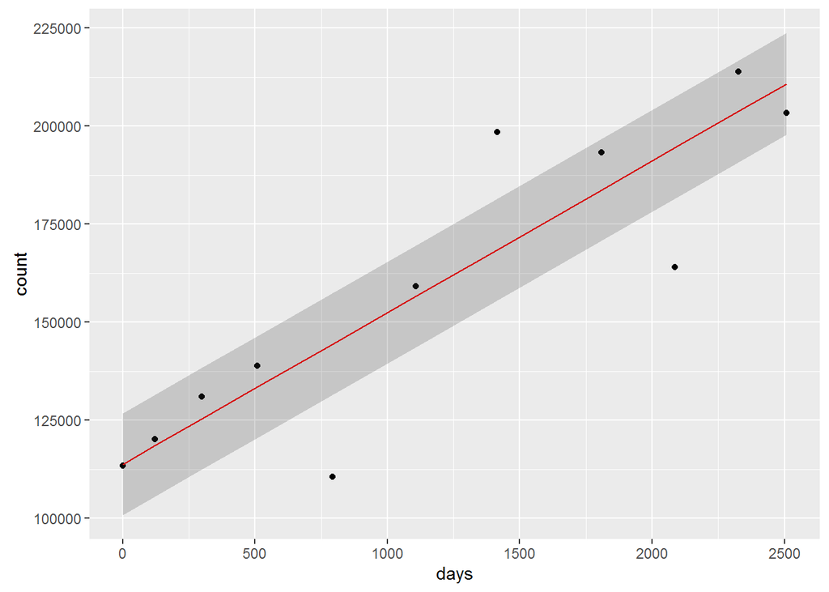

The normalized distance(ND)= 0.5677868

KB growth condition is 1 if ND<1 or KB growth is 0 if ND>=1

KB growth=1

### Class dbo Organisation

[http://dbpedia.org/ontology/Organisation]

Input: Set file location such as -

```r
location<- "/ExperimentalData/DBpedia/"
```

#### Persistency

Persistency Measure Result: 2016-04-01 value 359462 < 2015-10-02 value 435522. So Persistency= 0 Entity Count for 11 Release:

|  | version | Release | count | class |
| --- | --- | --- | --- | --- |
| 56 | 3.3 | 2009-05-20 | 105827 | dbo-organisation |
| 57 | 3.4 | 2009-09-20 | 118378 | dbo-organisation |
| 58 | 3.5 | 2010-03-16 | 140102 | dbo-organisation |
| 59 | 3.6 | 2010-10-11 | 147889 | dbo-organisation |
| 60 | 3.7 | 2011-07-22 | 169338 | dbo-organisation |
| 61 | 3.8 | 2012-06-01 | 192832 | dbo-organisation |
| 62 | 3.9 | 2013-04-03 | 329500 | dbo-organisation |
| 63 | 2014 | 2014-05-02 | 302658 | dbo-organisation |
| 64 | 2015-04 | 2015-02-05 | 322402 | dbo-organisation |
| 65 | 2015-10 | 2015-10-02 | 435522 | dbo-organisation |
| 66 | 2016-04 | 2016-04-01 | 359462 | dbo-organisation |

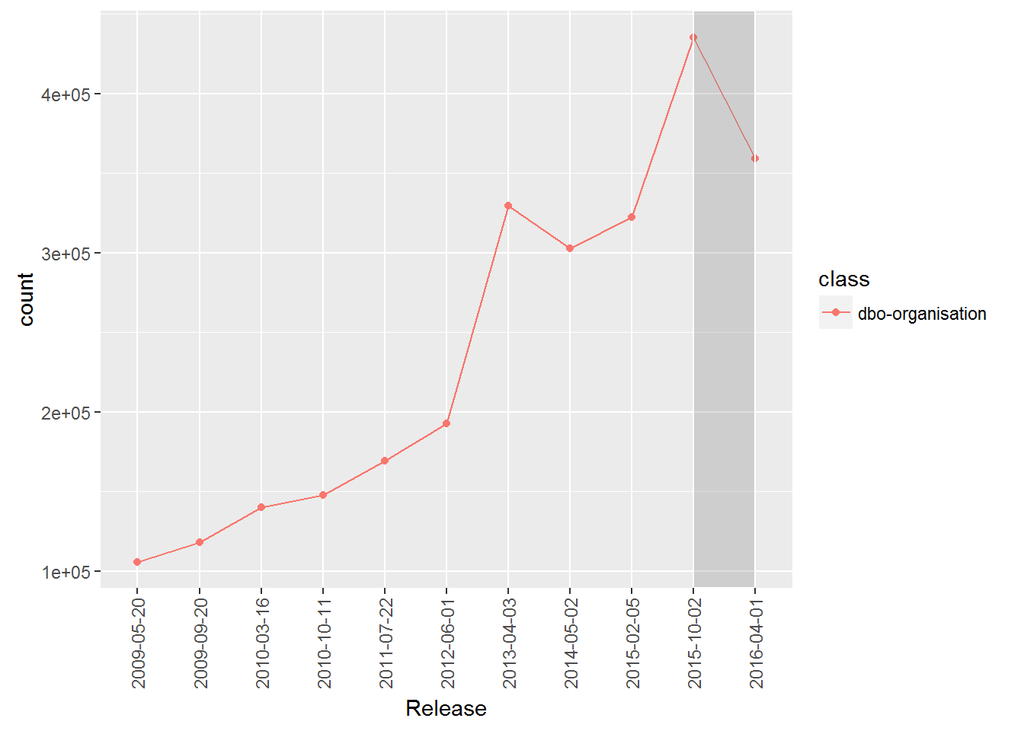

#### Historical Persitency

Historical Persistency Measure Result: Total no. of class = 10 and No. of persistency=2. HistPersistencyMeasure= 77.7777778 %

Releases with persistency values:

|  | version | Release | count | class | Persistency |
| --- | --- | --- | --- | --- | --- |
| 56 | 3.3 | 2009-05-20 | 105827 | dbo-organisation | 1 |
| 57 | 3.4 | 2009-09-20 | 118378 | dbo-organisation | 1 |
| 58 | 3.5 | 2010-03-16 | 140102 | dbo-organisation | 1 |
| 59 | 3.6 | 2010-10-11 | 147889 | dbo-organisation | 1 |
| 60 | 3.7 | 2011-07-22 | 169338 | dbo-organisation | 1 |
| 61 | 3.8 | 2012-06-01 | 192832 | dbo-organisation | 1 |
| 62 | 3.9 | 2013-04-03 | 329500 | dbo-organisation | 1 |
| 63 | 2014 | 2014-05-02 | 302658 | dbo-organisation | 0 |
| 64 | 2015-04 | 2015-02-05 | 322402 | dbo-organisation | 1 |
| 65 | 2015-10 | 2015-10-02 | 435522 | dbo-organisation | 1 |
| 66 | 2016-04 | 2016-04-01 | 359462 | dbo-organisation | 0 |

#### Consistency

No. of inconsistent property = 773

|  | property | v201604 | v201510 | v201502 |
| --- | --- | --- | --- | --- |
| 4 | http://dbpedia.org/ontology/Astronaut/timeInSpace | 0 | 2 | 4 |
| 17 | http://dbpedia.org/ontology/Automobile/wheelbase | 0 | 7 | 3 |
| 27 | http://dbpedia.org/ontology/Building/floorArea | 0 | 48 | 17 |
| 33 | http://dbpedia.org/ontology/Canal/maximumBoatBeam | 0 | 2 | 0 |
| 34 | http://dbpedia.org/ontology/Canal/maximumBoatLength | 0 | 2 | 0 |
| 64 | http://dbpedia.org/ontology/Infrastructure/length | 0 | 16 | 92 |
| 65 | http://dbpedia.org/ontology/Lake/areaOfCatchment | 0 | 31 | 5 |
| 66 | http://dbpedia.org/ontology/Lake/shoreLength | 0 | 35 | 7 |
| 67 | http://dbpedia.org/ontology/Lake/volume | 0 | 13 | 7 |
| 71 | http://dbpedia.org/ontology/MeanOfTransportation/diameter | 0 | 4 | 1 |
| 72 | http://dbpedia.org/ontology/MeanOfTransportation/height | 0 | 22 | 3 |
| 73 | http://dbpedia.org/ontology/MeanOfTransportation/length | 0 | 0 | 17 |
| 74 | http://dbpedia.org/ontology/MeanOfTransportation/mass | 0 | 3 | 1 |
| 78 | http://dbpedia.org/ontology/MeanOfTransportation/weight | 0 | 60 | 4 |
| 79 | http://dbpedia.org/ontology/MeanOfTransportation/width | 0 | 25 | 2 |
| 105 | http://dbpedia.org/ontology/Person/height | 0 | 0 | 83 |
| 111 | http://dbpedia.org/ontology/Person/weight | 0 | 0 | 59 |
| 120 | http://dbpedia.org/ontology/Planet/apoapsis | 0 | 15 | 16 |
| 121 | http://dbpedia.org/ontology/Planet/averageSpeed | 0 | 3 | 2 |
| 122 | http://dbpedia.org/ontology/Planet/density | 0 | 0 | 1 |
| 123 | http://dbpedia.org/ontology/Planet/maximumTemperature | 0 | 0 | 1 |
| 124 | http://dbpedia.org/ontology/Planet/meanTemperature | 0 | 0 | 1 |
| 125 | http://dbpedia.org/ontology/Planet/minimumTemperature | 0 | 0 | 1 |
| 126 | http://dbpedia.org/ontology/Planet/orbitalPeriod | 0 | 17 | 18 |
| 127 | http://dbpedia.org/ontology/Planet/periapsis | 0 | 15 | 16 |
| 128 | http://dbpedia.org/ontology/Planet/temperature | 0 | 3 | 2 |
| 129 | http://dbpedia.org/ontology/PopulatedPlace/area | 0 | 91 | 0 |
| 131 | http://dbpedia.org/ontology/PopulatedPlace/areaMetro | 0 | 1 | 1 |
| 132 | http://dbpedia.org/ontology/PopulatedPlace/areaUrban | 0 | 2 | 2 |
| 138 | http://dbpedia.org/ontology/PopulatedPlace/populationDensity | 0 | 0 | 91 |

[output cut: 743 more lines]

List of Consistent Property over last two version:

| Property | version201604 | version201510 | version201504 |
| --- | --- | --- | --- |
| http://dbpedia.org/ontology/MeanOfTransportation/length | 0 | 108 | 0 |
| http://dbpedia.org/ontology/Person/height | 0 | 215 | 0 |
| http://dbpedia.org/ontology/Person/weight | 0 | 174 | 0 |
| http://dbpedia.org/ontology/PopulatedPlace/areaTotal | 0 | 837 | 445 |
| http://dbpedia.org/ontology/PopulatedPlace/populationDensity | 0 | 192 | 0 |
| http://dbpedia.org/ontology/School/campusSize | 484 | 991 | 203 |
| http://dbpedia.org/ontology/Work/runtime | 0 | 222 | 443 |
| http://dbpedia.org/ontology/abbreviation | 1144 | 4478 | 2105 |
| http://dbpedia.org/ontology/abstract | 139013 | 367164 | 285720 |
| http://dbpedia.org/ontology/activeYearsEndYear | 12649 | 27011 | 24203 |
| http://dbpedia.org/ontology/activeYearsStartYear | 32634 | 46315 | 41722 |
| http://dbpedia.org/ontology/added | 0 | 108 | 143 |
| http://dbpedia.org/ontology/address | 0 | 16077 | 9384 |
| http://dbpedia.org/ontology/affiliation | 13011 | 19715 | 12089 |
| http://dbpedia.org/ontology/ageRange | 0 | 817 | 656 |
| http://dbpedia.org/ontology/airDate | 4635 | 0 | 0 |
| http://dbpedia.org/ontology/aircraftAttack | 192 | 463 | 665 |
| http://dbpedia.org/ontology/aircraftBomber | 0 | 367 | 409 |
| http://dbpedia.org/ontology/aircraftFighter | 407 | 1068 | 1568 |
| http://dbpedia.org/ontology/aircraftHelicopter | 0 | 306 | 404 |
| http://dbpedia.org/ontology/aircraftPatrol | 0 | 234 | 296 |
| http://dbpedia.org/ontology/aircraftRecon | 0 | 367 | 491 |
| http://dbpedia.org/ontology/aircraftTrainer | 145 | 679 | 869 |
| http://dbpedia.org/ontology/aircraftTransport | 153 | 851 | 1151 |
| http://dbpedia.org/ontology/alias | 3257 | 21589 | 14117 |
| http://dbpedia.org/ontology/alliance | 194 | 299 | 0 |
| http://dbpedia.org/ontology/almaMater | 0 | 250 | 283 |
| http://dbpedia.org/ontology/alumni | 0 | 225 | 142 |
| http://dbpedia.org/ontology/analogChannel | 0 | 1022 | 538 |
| http://dbpedia.org/ontology/anniversary | 104 | 187 | 152 |

[output cut: 340 more lines]

#### Completeness

Total no. of property =1143 No. of Consistent Property = 370 No. of incomplete property = 345

Percentage of completeness= 6.7567568 %

List of inincomplete property:

| property | Version201604 | Version201510 | NormFreqDiff |
| --- | --- | --- | --- |
| http://dbpedia.org/ontology/MeanOfTransportation/length | 0.0000000 | 0.0004655 | -0.0004655 |
| http://dbpedia.org/ontology/Person/height | 0.0000000 | 0.0009266 | -0.0009266 |
| http://dbpedia.org/ontology/Person/weight | 0.0000000 | 0.0007499 | -0.0007499 |
| http://dbpedia.org/ontology/PopulatedPlace/areaTotal | 0.0000000 | 0.0036075 | -0.0036075 |
| http://dbpedia.org/ontology/PopulatedPlace/populationDensity | 0.0000000 | 0.0008275 | -0.0008275 |
| http://dbpedia.org/ontology/School/campusSize | 0.0021232 | 0.0042712 | -0.0021481 |
| http://dbpedia.org/ontology/Work/runtime | 0.0000000 | 0.0009568 | -0.0009568 |
| http://dbpedia.org/ontology/abbreviation | 0.0050184 | 0.0193001 | -0.0142818 |
| http://dbpedia.org/ontology/abstract | 0.6098051 | 1.5824738 | -0.9726687 |
| http://dbpedia.org/ontology/activeYearsEndYear | 0.0554871 | 0.1164172 | -0.0609301 |
| http://dbpedia.org/ontology/activeYearsStartYear | 0.1431548 | 0.1996173 | -0.0564625 |
| http://dbpedia.org/ontology/added | 0.0000000 | 0.0004655 | -0.0004655 |
| http://dbpedia.org/ontology/address | 0.0000000 | 0.0692917 | -0.0692917 |
| http://dbpedia.org/ontology/affiliation | 0.0570751 | 0.0849715 | -0.0278964 |
| http://dbpedia.org/ontology/ageRange | 0.0000000 | 0.0035213 | -0.0035213 |
| http://dbpedia.org/ontology/aircraftAttack | 0.0008422 | 0.0019955 | -0.0011533 |
| http://dbpedia.org/ontology/aircraftBomber | 0.0000000 | 0.0015818 | -0.0015818 |
| http://dbpedia.org/ontology/aircraftFighter | 0.0017854 | 0.0046031 | -0.0028177 |
| http://dbpedia.org/ontology/aircraftHelicopter | 0.0000000 | 0.0013189 | -0.0013189 |
| http://dbpedia.org/ontology/aircraftPatrol | 0.0000000 | 0.0010085 | -0.0010085 |
| http://dbpedia.org/ontology/aircraftRecon | 0.0000000 | 0.0015818 | -0.0015818 |
| http://dbpedia.org/ontology/aircraftTrainer | 0.0006361 | 0.0029265 | -0.0022904 |
| http://dbpedia.org/ontology/aircraftTransport | 0.0006712 | 0.0036678 | -0.0029966 |
| http://dbpedia.org/ontology/alias | 0.0142874 | 0.0930484 | -0.0787610 |
| http://dbpedia.org/ontology/alliance | 0.0008510 | 0.0012887 | -0.0004377 |
| http://dbpedia.org/ontology/almaMater | 0.0000000 | 0.0010775 | -0.0010775 |
| http://dbpedia.org/ontology/alumni | 0.0000000 | 0.0009697 | -0.0009697 |
| http://dbpedia.org/ontology/analogChannel | 0.0000000 | 0.0044048 | -0.0044048 |
| http://dbpedia.org/ontology/anniversary | 0.0004562 | 0.0008060 | -0.0003498 |
| http://dbpedia.org/ontology/architect | 0.0000000 | 0.0005043 | -0.0005043 |

[output cut: 315 more lines]

#### KB growth

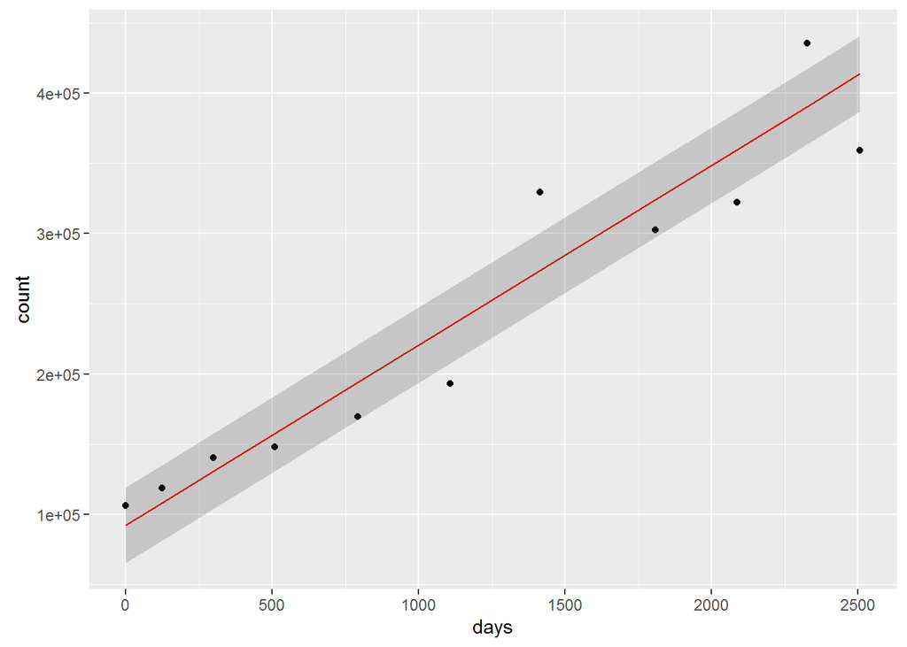

The normalized distance(ND)= 2.0270691

KB growth is 1 if ND<1 or KB growth is 0 if ND>=1

KB growth=0

### Class dbo Place

[http://dbpedia.org/ontology/Place]

Input: Set file location such as -

```r
location<- "/ExperimentalData/DBpedia/"
```

#### Persistency

Persistency Measure Result: 2016-04-01 value 925383 < 2015-10-02 value 1122785. So Persistency= 0 Entity Count for 11 Release:

|  | version | Release | count | class |
| --- | --- | --- | --- | --- |
| 67 | 3.3 | 2009-05-20 | 318017 | dbo-place |
| 68 | 3.4 | 2009-09-20 | 337551 | dbo-place |
| 69 | 3.5 | 2010-03-16 | 413423 | dbo-place |
| 70 | 3.5 | 2010-03-16 | 413423 | dbo-place |
| 71 | 3.7 | 2011-07-22 | 525786 | dbo-place |
| 72 | 3.8 | 2012-06-01 | 572728 | dbo-place |
| 73 | 3.9 | 2013-04-03 | 754415 | dbo-place |
| 74 | 2014 | 2014-05-02 | 816837 | dbo-place |
| 75 | 2015-04 | 2015-02-05 | 943799 | dbo-place |
| 76 | 2015-10 | 2015-10-02 | 1122785 | dbo-place |
| 77 | 2016-04 | 2016-04-01 | 925383 | dbo-place |

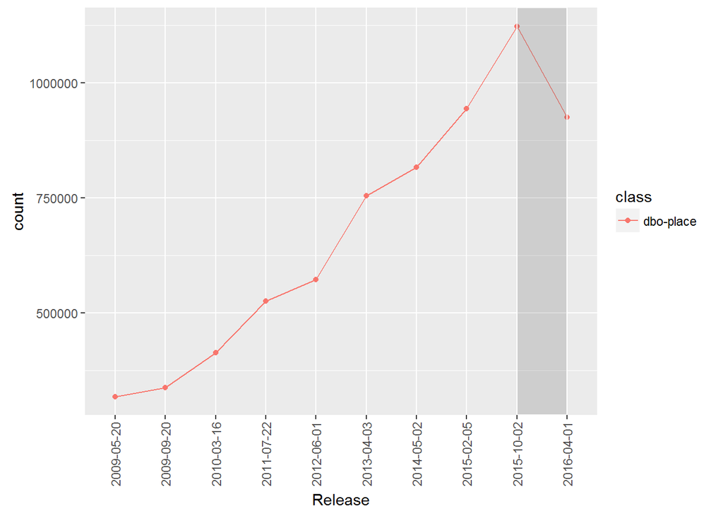

#### Historical Persitency

Historical Persistency Measure Result: Total no. of class = 10 and No. of persistency=1. HistPersistencyMeasure= 88.8888889 %

Releases with persistency values:

|  | version | Release | count | class | Persistency |
| --- | --- | --- | --- | --- | --- |
| 67 | 3.3 | 2009-05-20 | 318017 | dbo-place | 1 |
| 68 | 3.4 | 2009-09-20 | 337551 | dbo-place | 1 |
| 69 | 3.5 | 2010-03-16 | 413423 | dbo-place | 1 |
| 70 | 3.5 | 2010-03-16 | 413423 | dbo-place | 1 |
| 71 | 3.7 | 2011-07-22 | 525786 | dbo-place | 1 |
| 72 | 3.8 | 2012-06-01 | 572728 | dbo-place | 1 |
| 73 | 3.9 | 2013-04-03 | 754415 | dbo-place | 1 |
| 74 | 2014 | 2014-05-02 | 816837 | dbo-place | 1 |
| 75 | 2015-04 | 2015-02-05 | 943799 | dbo-place | 1 |
| 76 | 2015-10 | 2015-10-02 | 1122785 | dbo-place | 1 |
| 77 | 2016-04 | 2016-04-01 | 925383 | dbo-place | 0 |

#### Consistency

No. of inconsistent property = 714

|  | property | v201604 | v201510 | v201502 |
| --- | --- | --- | --- | --- |
| 5 | http://dbpedia.org/ontology/Astronaut/timeInSpace | 0 | 2 | 2 |
| 6 | http://dbpedia.org/ontology/Automobile/wheelbase | 0 | 16 | 0 |
| 30 | http://dbpedia.org/ontology/Canal/maximumBoatBeam | 0 | 79 | 14 |
| 31 | http://dbpedia.org/ontology/Canal/maximumBoatLength | 0 | 77 | 14 |
| 33 | http://dbpedia.org/ontology/Canal/originalMaximumBoatBeam | 0 | 7 | 3 |
| 34 | http://dbpedia.org/ontology/Canal/originalMaximumBoatLength | 0 | 5 | 1 |
| 101 | http://dbpedia.org/ontology/MeanOfTransportation/diameter | 0 | 19 | 1 |
| 102 | http://dbpedia.org/ontology/MeanOfTransportation/height | 0 | 26 | 1 |
| 103 | http://dbpedia.org/ontology/MeanOfTransportation/length | 0 | 0 | 2 |
| 104 | http://dbpedia.org/ontology/MeanOfTransportation/mass | 0 | 29 | 0 |
| 105 | http://dbpedia.org/ontology/MeanOfTransportation/weight | 0 | 8 | 1 |
| 106 | http://dbpedia.org/ontology/MeanOfTransportation/width | 0 | 22 | 0 |
| 165 | http://dbpedia.org/ontology/Person/height | 0 | 37 | 13 |
| 171 | http://dbpedia.org/ontology/Person/weight | 0 | 25 | 6 |
| 172 | http://dbpedia.org/ontology/Planet/apoapsis | 0 | 0 | 1 |
| 173 | http://dbpedia.org/ontology/Planet/maximumTemperature | 0 | 22 | 0 |
| 174 | http://dbpedia.org/ontology/Planet/meanRadius | 0 | 45 | 0 |
| 175 | http://dbpedia.org/ontology/Planet/meanTemperature | 0 | 36 | 0 |
| 176 | http://dbpedia.org/ontology/Planet/minimumTemperature | 0 | 18 | 0 |
| 177 | http://dbpedia.org/ontology/Planet/orbitalPeriod | 0 | 0 | 1 |
| 178 | http://dbpedia.org/ontology/Planet/periapsis | 0 | 0 | 1 |
| 179 | http://dbpedia.org/ontology/Planet/surfaceArea | 0 | 38 | 0 |
| 180 | http://dbpedia.org/ontology/Planet/volume | 0 | 63 | 0 |
| 185 | http://dbpedia.org/ontology/PopulatedPlace/populationUrbanDensity | 67 | 0 | 0 |
| 203 | http://dbpedia.org/ontology/Rocket/lowerEarthOrbitPayload | 0 | 1 | 0 |
| 204 | http://dbpedia.org/ontology/Rocket/mass | 0 | 3 | 0 |
| 207 | http://dbpedia.org/ontology/School/campusSize | 0 | 50 | 10 |
| 244 | http://dbpedia.org/ontology/SpaceStation/volume | 0 | 22 | 1 |
| 268 | http://dbpedia.org/ontology/Weapon/diameter | 0 | 8 | 0 |
| 269 | http://dbpedia.org/ontology/Weapon/height | 0 | 13 | 0 |

[output cut: 684 more lines]

List of Consistent Property over last two version:

| Property | version201604 | version201510 | version201504 |
| --- | --- | --- | --- |
| http://dbpedia.org/ontology/Bridge/mainspan | 792 | 0 | 0 |
| http://dbpedia.org/ontology/Building/floorArea | 1652 | 3766 | 670 |
| http://dbpedia.org/ontology/Infrastructure/length | 0 | 22700 | 18054 |
| http://dbpedia.org/ontology/Lake/areaOfCatchment | 717 | 1042 | 352 |
| http://dbpedia.org/ontology/Lake/shoreLength | 1060 | 1588 | 619 |
| http://dbpedia.org/ontology/Lake/volume | 0 | 1382 | 724 |
| http://dbpedia.org/ontology/MeanOfTransportation/length | 0 | 217 | 0 |
| http://dbpedia.org/ontology/Planet/apoapsis | 0 | 3075 | 0 |
| http://dbpedia.org/ontology/Planet/averageSpeed | 0 | 748 | 0 |
| http://dbpedia.org/ontology/Planet/density | 0 | 130 | 0 |
| http://dbpedia.org/ontology/Planet/mass | 0 | 198 | 0 |
| http://dbpedia.org/ontology/Planet/orbitalPeriod | 0 | 3254 | 0 |
| http://dbpedia.org/ontology/Planet/periapsis | 0 | 3098 | 0 |
| http://dbpedia.org/ontology/Planet/temperature | 0 | 483 | 0 |
| http://dbpedia.org/ontology/PopulatedPlace/area | 0 | 41608 | 41125 |
| http://dbpedia.org/ontology/PopulatedPlace/areaMetro | 0 | 748 | 675 |
| http://dbpedia.org/ontology/PopulatedPlace/areaTotal | 0 | 161360 | 146846 |
| http://dbpedia.org/ontology/PopulatedPlace/areaUrban | 259 | 643 | 594 |
| http://dbpedia.org/ontology/PopulatedPlace/populationDensity | 0 | 75691 | 71409 |
| http://dbpedia.org/ontology/PopulatedPlace/populationMetroDensity | 168 | 233 | 226 |
| http://dbpedia.org/ontology/PopulatedPlace/populationUrbanDensity | 0 | 160 | 143 |
| http://dbpedia.org/ontology/Stream/discharge | 0 | 2105 | 1437 |
| http://dbpedia.org/ontology/Stream/dischargeAverage | 0 | 143 | 142 |
| http://dbpedia.org/ontology/Stream/maximumDischarge | 0 | 947 | 924 |
| http://dbpedia.org/ontology/Stream/minimumDischarge | 0 | 887 | 865 |
| http://dbpedia.org/ontology/Stream/watershed | 1706 | 3405 | 1551 |
| http://dbpedia.org/ontology/Work/runtime | 0 | 172 | 0 |
| http://dbpedia.org/ontology/abbreviation | 0 | 142 | 1094 |
| http://dbpedia.org/ontology/absoluteMagnitude | 0 | 2607 | 0 |
| http://dbpedia.org/ontology/abstract | 411298 | 909670 | 722776 |

[output cut: 450 more lines]

#### Completeness

Total no. of property =1194 No. of Consistent Property = 480 No. of incomplete property = 452

Percentage of completeness= 5.8333333 %

List of inincomplete property:

| property | Version201604 | Version201510 | NormFreqDiff |
| --- | --- | --- | --- |
| http://dbpedia.org/ontology/Building/floorArea | 0.0072468 | 0.0162314 | -0.0089846 |
| http://dbpedia.org/ontology/Infrastructure/length | 0.0000000 | 0.0978368 | -0.0978368 |
| http://dbpedia.org/ontology/Lake/areaOfCatchment | 0.0031452 | 0.0044910 | -0.0013458 |
| http://dbpedia.org/ontology/Lake/shoreLength | 0.0046499 | 0.0068443 | -0.0021944 |
| http://dbpedia.org/ontology/Lake/volume | 0.0000000 | 0.0059564 | -0.0059564 |
| http://dbpedia.org/ontology/MeanOfTransportation/length | 0.0000000 | 0.0009353 | -0.0009353 |
| http://dbpedia.org/ontology/Planet/apoapsis | 0.0000000 | 0.0132532 | -0.0132532 |
| http://dbpedia.org/ontology/Planet/averageSpeed | 0.0000000 | 0.0032239 | -0.0032239 |
| http://dbpedia.org/ontology/Planet/density | 0.0000000 | 0.0005603 | -0.0005603 |
| http://dbpedia.org/ontology/Planet/mass | 0.0000000 | 0.0008534 | -0.0008534 |
| http://dbpedia.org/ontology/Planet/orbitalPeriod | 0.0000000 | 0.0140247 | -0.0140247 |
| http://dbpedia.org/ontology/Planet/periapsis | 0.0000000 | 0.0133524 | -0.0133524 |
| http://dbpedia.org/ontology/Planet/temperature | 0.0000000 | 0.0020817 | -0.0020817 |
| http://dbpedia.org/ontology/PopulatedPlace/area | 0.0000000 | 0.1793301 | -0.1793301 |
| http://dbpedia.org/ontology/PopulatedPlace/areaMetro | 0.0000000 | 0.0032239 | -0.0032239 |
| http://dbpedia.org/ontology/PopulatedPlace/areaTotal | 0.0000000 | 0.6954603 | -0.6954603 |
| http://dbpedia.org/ontology/PopulatedPlace/areaUrban | 0.0011361 | 0.0027713 | -0.0016352 |
| http://dbpedia.org/ontology/PopulatedPlace/populationDensity | 0.0000000 | 0.3262276 | -0.3262276 |
| http://dbpedia.org/ontology/PopulatedPlace/populationMetroDensity | 0.0007370 | 0.0010042 | -0.0002673 |
| http://dbpedia.org/ontology/PopulatedPlace/populationUrbanDensity | 0.0000000 | 0.0006896 | -0.0006896 |
| http://dbpedia.org/ontology/Stream/discharge | 0.0000000 | 0.0090725 | -0.0090725 |
| http://dbpedia.org/ontology/Stream/dischargeAverage | 0.0000000 | 0.0006163 | -0.0006163 |
| http://dbpedia.org/ontology/Stream/maximumDischarge | 0.0000000 | 0.0040816 | -0.0040816 |
| http://dbpedia.org/ontology/Stream/minimumDischarge | 0.0000000 | 0.0038230 | -0.0038230 |
| http://dbpedia.org/ontology/Stream/watershed | 0.0074837 | 0.0146755 | -0.0071919 |
| http://dbpedia.org/ontology/Work/runtime | 0.0000000 | 0.0007413 | -0.0007413 |
| http://dbpedia.org/ontology/abbreviation | 0.0000000 | 0.0006120 | -0.0006120 |
| http://dbpedia.org/ontology/absoluteMagnitude | 0.0000000 | 0.0112361 | -0.0112361 |
| http://dbpedia.org/ontology/abstract | 1.8042314 | 3.9206703 | -2.1164389 |
| http://dbpedia.org/ontology/access | 0.0000000 | 0.0012240 | -0.0012240 |

[output cut: 422 more lines]

#### KB growth

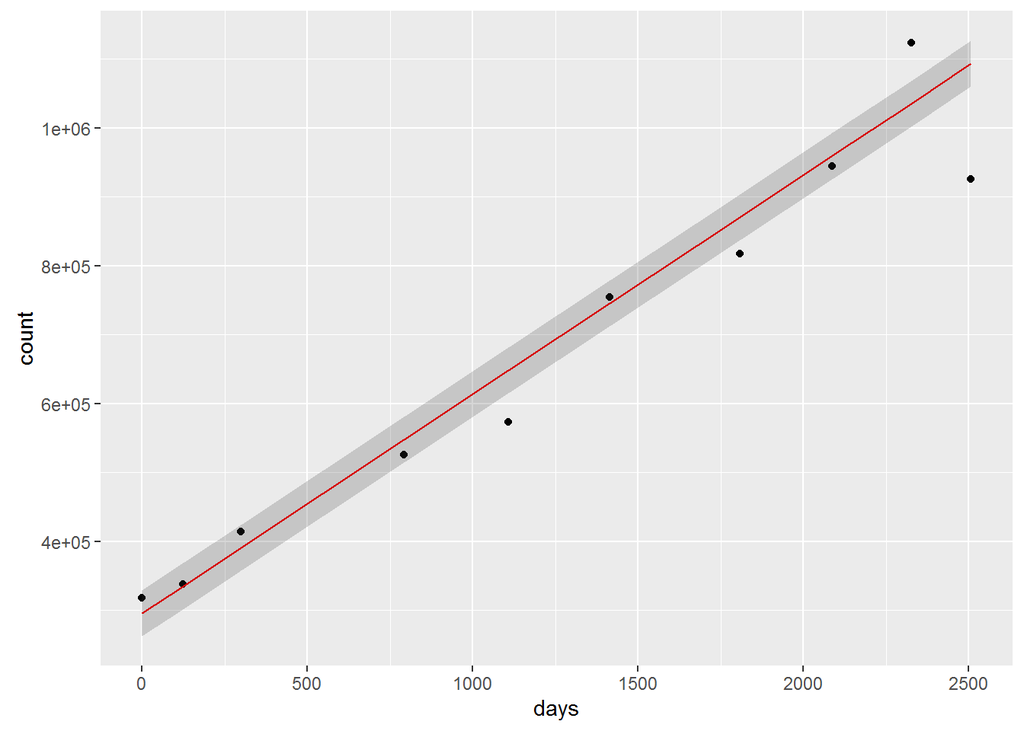

The normalized distance(ND)= 5.0381527

KB growth condition is 1 if ND<1 or KB growth is 0 if ND>=1

KB growth=0

### Class dbo Species

[http://dbpedia.org/ontology/Species]

Input: Set file location such as -

```r
location<- "/ExperimentalData/DBpedia/"
```

#### Persistency

Persistency Measure Result: 2016-04-01 value 301715 < 2015-10-02 value 305378. So Persistency= 0 Entity Count for 11 Release:

|  | version | Release | count | class |
| --- | --- | --- | --- | --- |
| 78 | 3.3 | 2009-05-20 | 118042 | dbo-species |
| 79 | 3.4 | 2009-09-20 | 130466 | dbo-species |
| 80 | 3.5 | 2010-03-16 | 146082 | dbo-species |
| 81 | 3.6 | 2010-10-11 | 168575 | dbo-species |
| 82 | 3.7 | 2011-07-22 | 182848 | dbo-species |
| 83 | 3.8 | 2012-06-01 | 202339 | dbo-species |
| 84 | 3.9 | 2013-04-03 | 239194 | dbo-species |
| 85 | 2014 | 2014-05-02 | 261435 | dbo-species |
| 86 | 2015-04 | 2015-02-05 | 285320 | dbo-species |
| 87 | 2015-10 | 2015-10-02 | 305378 | dbo-species |
| 88 | 2016-04 | 2016-04-01 | 301715 | dbo-species |

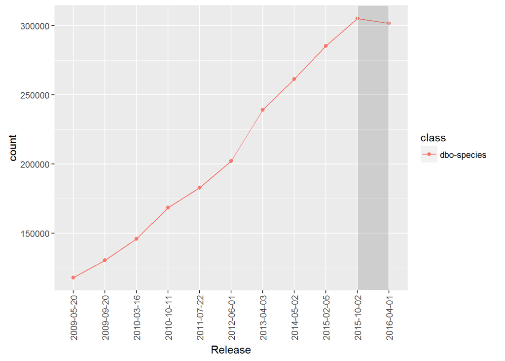

#### Historical Persitency

Historical Persistency Measure Result: Total no. of class = 10 and No. of persistency=1. HistPersistencyMeasure= 88.8888889 %

Releases with persistency values:

|  | version | Release | count | class | Persistency |
| --- | --- | --- | --- | --- | --- |
| 78 | 3.3 | 2009-05-20 | 118042 | dbo-species | 1 |
| 79 | 3.4 | 2009-09-20 | 130466 | dbo-species | 1 |
| 80 | 3.5 | 2010-03-16 | 146082 | dbo-species | 1 |
| 81 | 3.6 | 2010-10-11 | 168575 | dbo-species | 1 |
| 82 | 3.7 | 2011-07-22 | 182848 | dbo-species | 1 |
| 83 | 3.8 | 2012-06-01 | 202339 | dbo-species | 1 |
| 84 | 3.9 | 2013-04-03 | 239194 | dbo-species | 1 |
| 85 | 2014 | 2014-05-02 | 261435 | dbo-species | 1 |
| 86 | 2015-04 | 2015-02-05 | 285320 | dbo-species | 1 |
| 87 | 2015-10 | 2015-10-02 | 305378 | dbo-species | 1 |
| 88 | 2016-04 | 2016-04-01 | 301715 | dbo-species | 0 |

#### Consistency

No. of inconsistent property = 99

|  | property | v201604 | v201510 | v201502 |
| --- | --- | --- | --- | --- |
| 10 | http://dbpedia.org/ontology/Work/runtime | 0 | 2 | 6 |
| 11 | http://dbpedia.org/ontology/activeYearsEndYear | 0 | 2 | 3 |
| 12 | http://dbpedia.org/ontology/activeYearsStartYear | 0 | 2 | 3 |
| 13 | http://dbpedia.org/ontology/added | 0 | 0 | 1 |
| 14 | http://dbpedia.org/ontology/address | 0 | 0 | 1 |
| 15 | http://dbpedia.org/ontology/album | 0 | 1 | 3 |
| 16 | http://dbpedia.org/ontology/alias | 0 | 0 | 2 |
| 17 | http://dbpedia.org/ontology/almaMater | 0 | 1 | 1 |
| 18 | http://dbpedia.org/ontology/areaCode | 0 | 0 | 1 |
| 19 | http://dbpedia.org/ontology/artist | 0 | 1 | 2 |
| 20 | http://dbpedia.org/ontology/atcPrefix | 0 | 2 | 1 |
| 21 | http://dbpedia.org/ontology/atcSuffix | 0 | 1 | 1 |
| 22 | http://dbpedia.org/ontology/bSide | 0 | 1 | 7 |
| 23 | http://dbpedia.org/ontology/binomial | 55 | 0 | 0 |
| 24 | http://dbpedia.org/ontology/birthDate | 0 | 5 | 83 |
| 25 | http://dbpedia.org/ontology/birthName | 0 | 1 | 1 |
| 26 | http://dbpedia.org/ontology/birthPlace | 0 | 4 | 86 |
| 27 | http://dbpedia.org/ontology/birthYear | 0 | 4 | 8 |
| 28 | http://dbpedia.org/ontology/builder | 0 | 1 | 1 |
| 29 | http://dbpedia.org/ontology/casNumber | 0 | 3 | 1 |
| 30 | http://dbpedia.org/ontology/causalties | 0 | 0 | 2 |
| 31 | http://dbpedia.org/ontology/child | 0 | 0 | 1 |
| 32 | http://dbpedia.org/ontology/city | 0 | 0 | 1 |
| 33 | http://dbpedia.org/ontology/combatant | 0 | 0 | 10 |
| 34 | http://dbpedia.org/ontology/commander | 0 | 0 | 18 |
| 36 | http://dbpedia.org/ontology/creator | 0 | 0 | 4 |
| 37 | http://dbpedia.org/ontology/cultivatedVariety | 0 | 18 | 6 |
| 38 | http://dbpedia.org/ontology/cylinderCount | 0 | 1 | 1 |
| 39 | http://dbpedia.org/ontology/deathDate | 0 | 2 | 37 |
| 40 | http://dbpedia.org/ontology/deathPlace | 0 | 2 | 43 |

[output cut: 69 more lines]

List of Consistent Property over last two version:

| Property | version201604 | version201510 | version201504 |
| --- | --- | --- | --- |
| http://dbpedia.org/ontology/abstract | 145822 | 296477 | 277814 |
| http://dbpedia.org/ontology/award | 0 | 1996 | 1932 |
| http://dbpedia.org/ontology/binomial | 0 | 629 | 1077 |
| http://dbpedia.org/ontology/binomialAuthority | 43684 | 90790 | 100076 |
| http://dbpedia.org/ontology/breeder | 0 | 1779 | 1569 |
| http://dbpedia.org/ontology/class | 153751 | 296343 | 328053 |
| http://dbpedia.org/ontology/color | 3411 | 0 | 0 |
| http://dbpedia.org/ontology/colour | 0 | 3472 | 2798 |
| http://dbpedia.org/ontology/colourName | 0 | 3904 | 3550 |
| http://dbpedia.org/ontology/conservationStatus | 42322 | 48284 | 48158 |
| http://dbpedia.org/ontology/conservationStatusSystem | 40596 | 47294 | 47073 |
| http://dbpedia.org/ontology/country | 0 | 2612 | 2035 |
| http://dbpedia.org/ontology/dam | 0 | 450 | 369 |
| http://dbpedia.org/ontology/damsire | 0 | 2275 | 1727 |
| http://dbpedia.org/ontology/division | 44934 | 62017 | 104932 |
| http://dbpedia.org/ontology/domain | 1647 | 3216 | 5034 |
| http://dbpedia.org/ontology/family | 215105 | 376170 | 431678 |
| http://dbpedia.org/ontology/foalDate | 0 | 1001 | 462 |
| http://dbpedia.org/ontology/genus | 88252 | 212681 | 209779 |
| http://dbpedia.org/ontology/grandsire | 0 | 2978 | 2274 |
| http://dbpedia.org/ontology/honours | 0 | 1061 | 919 |
| http://dbpedia.org/ontology/hybrid | 0 | 1904 | 0 |
| http://dbpedia.org/ontology/kingdom | 145800 | 284532 | 339956 |
| http://dbpedia.org/ontology/order | 174654 | 335893 | 345695 |
| http://dbpedia.org/ontology/origin | 187 | 1137 | 487 |
| http://dbpedia.org/ontology/owner | 0 | 2535 | 2178 |
| http://dbpedia.org/ontology/phylum | 109367 | 235392 | 266140 |
| http://dbpedia.org/ontology/race | 0 | 16292 | 14136 |
| http://dbpedia.org/ontology/sex | 0 | 3689 | 2753 |
| http://dbpedia.org/ontology/sire | 0 | 2832 | 2096 |
| http://dbpedia.org/ontology/soundRecording | 0 | 305 | 331 |
| http://dbpedia.org/ontology/species | 1568 | 2550 | 3017 |
| http://dbpedia.org/ontology/synonym | 49048 | 230944 | 212728 |
| http://dbpedia.org/ontology/thumbnail | 48077 | 98013 | 94181 |
| http://dbpedia.org/ontology/trainer | 0 | 3341 | 2687 |
| http://dbpedia.org/ontology/wikiPageExternalLink | 0 | 226925 | 229804 |
| http://dbpedia.org/ontology/wikiPageID | 0 | 296726 | 280646 |
| http://dbpedia.org/ontology/wikiPageLength | 0 | 296726 | 280646 |
| http://dbpedia.org/ontology/wikiPageOutDegree | 0 | 296726 | 280646 |
| http://dbpedia.org/ontology/wikiPageRevisionID | 0 | 296726 | 280646 |
| http://dbpedia.org/ontology/wikiPageWikiLink | 0 | 6991276 | 6673834 |
| http://dbpedia.org/ontology/wikiPageWikiLinkText | 0 | 437376 | 416709 |
| http://dbpedia.org/ontology/wineRegion | 0 | 410 | 496 |

#### Completeness

Total no. of property =142 No. of Consistent Property = 43 No. of incomplete property = 42

Percentage of completeness= 2.3255814 %

List of inincomplete property:

| property | Version201604 | Version201510 | NormFreqDiff |
| --- | --- | --- | --- |
| http://dbpedia.org/ontology/abstract | 0.6396740 | 1.2778135 | -0.6381395 |
| http://dbpedia.org/ontology/award | 0.0000000 | 0.0086027 | -0.0086027 |
| http://dbpedia.org/ontology/binomial | 0.0000000 | 0.0027110 | -0.0027110 |
| http://dbpedia.org/ontology/binomialAuthority | 0.1916276 | 0.3913042 | -0.1996766 |
| http://dbpedia.org/ontology/breeder | 0.0000000 | 0.0076675 | -0.0076675 |
| http://dbpedia.org/ontology/class | 0.6744559 | 1.2772359 | -0.6027800 |
| http://dbpedia.org/ontology/colour | 0.0000000 | 0.0149643 | -0.0149643 |
| http://dbpedia.org/ontology/colourName | 0.0000000 | 0.0168262 | -0.0168262 |
| http://dbpedia.org/ontology/conservationStatus | 0.1856529 | 0.2081036 | -0.0224507 |
| http://dbpedia.org/ontology/conservationStatusSystem | 0.1780815 | 0.2038368 | -0.0257552 |
| http://dbpedia.org/ontology/country | 0.0000000 | 0.0112577 | -0.0112577 |
| http://dbpedia.org/ontology/dam | 0.0000000 | 0.0019395 | -0.0019395 |
| http://dbpedia.org/ontology/damsire | 0.0000000 | 0.0098052 | -0.0098052 |
| http://dbpedia.org/ontology/division | 0.1971109 | 0.2672928 | -0.0701818 |
| http://dbpedia.org/ontology/domain | 0.0072249 | 0.0138609 | -0.0066361 |
| http://dbpedia.org/ontology/family | 0.9435961 | 1.6212896 | -0.6776935 |
| http://dbpedia.org/ontology/foalDate | 0.0000000 | 0.0043143 | -0.0043143 |
| http://dbpedia.org/ontology/genus | 0.3871330 | 0.9166534 | -0.5295204 |
| http://dbpedia.org/ontology/grandsire | 0.0000000 | 0.0128352 | -0.0128352 |
| http://dbpedia.org/ontology/honours | 0.0000000 | 0.0045729 | -0.0045729 |
| http://dbpedia.org/ontology/hybrid | 0.0000000 | 0.0082062 | -0.0082062 |
| http://dbpedia.org/ontology/kingdom | 0.6395775 | 1.2263306 | -0.5867531 |
| http://dbpedia.org/ontology/order | 0.7661506 | 1.4476961 | -0.6815454 |
| http://dbpedia.org/ontology/origin | 0.0008203 | 0.0049005 | -0.0040802 |
| http://dbpedia.org/ontology/owner | 0.0000000 | 0.0109258 | -0.0109258 |
| http://dbpedia.org/ontology/phylum | 0.4797577 | 1.0145376 | -0.5347799 |
| http://dbpedia.org/ontology/race | 0.0000000 | 0.0702184 | -0.0702184 |
| http://dbpedia.org/ontology/sex | 0.0000000 | 0.0158996 | -0.0158996 |
| http://dbpedia.org/ontology/sire | 0.0000000 | 0.0122059 | -0.0122059 |
| http://dbpedia.org/ontology/soundRecording | 0.0000000 | 0.0013145 | -0.0013145 |
| http://dbpedia.org/ontology/species | 0.0068783 | 0.0109905 | -0.0041122 |
| http://dbpedia.org/ontology/synonym | 0.2151577 | 0.9953668 | -0.7802090 |
| http://dbpedia.org/ontology/thumbnail | 0.2108983 | 0.4224352 | -0.2115370 |
| http://dbpedia.org/ontology/trainer | 0.0000000 | 0.0143997 | -0.0143997 |
| http://dbpedia.org/ontology/wikiPageExternalLink | 0.0000000 | 0.9780449 | -0.9780449 |
| http://dbpedia.org/ontology/wikiPageID | 0.0000000 | 1.2788866 | -1.2788866 |
| http://dbpedia.org/ontology/wikiPageLength | 0.0000000 | 1.2788866 | -1.2788866 |
| http://dbpedia.org/ontology/wikiPageOutDegree | 0.0000000 | 1.2788866 | -1.2788866 |
| http://dbpedia.org/ontology/wikiPageRevisionID | 0.0000000 | 1.2788866 | -1.2788866 |
| http://dbpedia.org/ontology/wikiPageWikiLink | 0.0000000 | 30.1323426 | -30.1323426 |
| http://dbpedia.org/ontology/wikiPageWikiLinkText | 0.0000000 | 1.8850870 | -1.8850870 |
| http://dbpedia.org/ontology/wineRegion | 0.0000000 | 0.0017671 | -0.0017671 |

#### KB growth

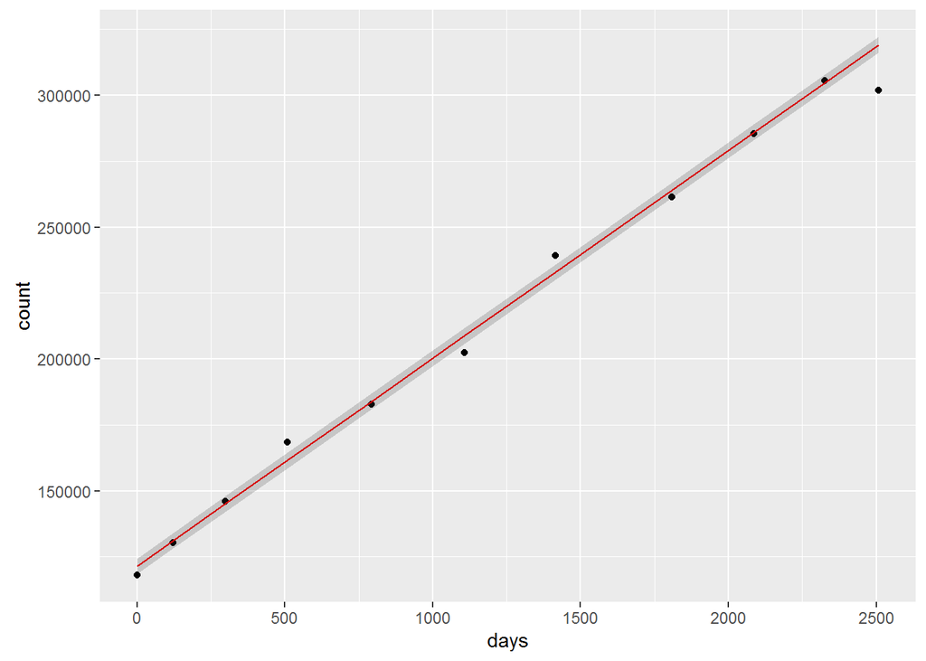

The normalized distance(ND)= 5.8781797

KB growth is 1 if ND<1 or KB growth is 0 if ND>=1

KB growth=0

### Class dbo Work

[http://dbpedia.org/ontology/Work]

Input: Set file location such as -

```r
location<- "/ExperimentalData/DBpedia/"
```

#### Persistency

Persistency Measure Result: 2016-04-01 value 571847 < 2015-10-02 value 683923. So Persistency= 0 Entity Count for 11 Release:

|  | version | Release | count | class |
| --- | --- | --- | --- | --- |
| 89 | 3.3 | 2009-05-20 | 213231 | dbo-work |
| 90 | 3.4 | 2009-09-20 | 229152 | dbo-work |
| 91 | 3.5 | 2010-03-16 | 320054 | dbo-work |
| 92 | 3.6 | 2010-10-11 | 355100 | dbo-work |
| 93 | 3.7 | 2011-07-22 | 262662 | dbo-work |
| 94 | 3.8 | 2012-06-01 | 333270 | dbo-work |
| 95 | 3.9 | 2013-04-03 | 409594 | dbo-work |
| 96 | 2014 | 2014-05-02 | 425044 | dbo-work |
| 97 | 2015-04 | 2015-02-05 | 588205 | dbo-work |
| 98 | 2015-10 | 2015-10-02 | 683923 | dbo-work |
| 99 | 2016-04 | 2016-04-01 | 571847 | dbo-work |

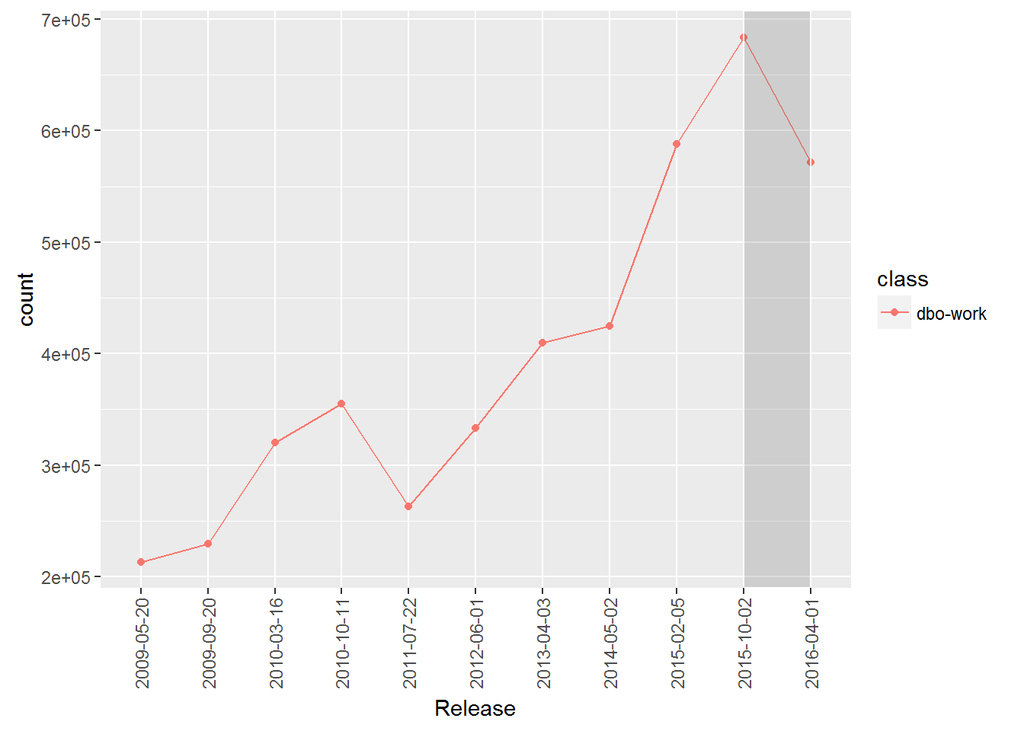

#### Historical Persitency

Historical Persistency Measure Result: Total no. of class = 10 and No. of persistency=2. HistPersistencyMeasure= 77.7777778 %

Releases with persistency values:

|  | version | Release | count | class | Persistency |
| --- | --- | --- | --- | --- | --- |
| 89 | 3.3 | 2009-05-20 | 213231 | dbo-work | 1 |
| 90 | 3.4 | 2009-09-20 | 229152 | dbo-work | 1 |
| 91 | 3.5 | 2010-03-16 | 320054 | dbo-work | 1 |
| 92 | 3.6 | 2010-10-11 | 355100 | dbo-work | 1 |
| 93 | 3.7 | 2011-07-22 | 262662 | dbo-work | 0 |
| 94 | 3.8 | 2012-06-01 | 333270 | dbo-work | 1 |
| 95 | 3.9 | 2013-04-03 | 409594 | dbo-work | 1 |
| 96 | 2014 | 2014-05-02 | 425044 | dbo-work | 1 |
| 97 | 2015-04 | 2015-02-05 | 588205 | dbo-work | 1 |
| 98 | 2015-10 | 2015-10-02 | 683923 | dbo-work | 1 |
| 99 | 2016-04 | 2016-04-01 | 571847 | dbo-work | 0 |

#### Consistency

No. of inconsistent property = 710

|  | property | v201604 | v201510 | v201502 |
| --- | --- | --- | --- | --- |
| 3 | http://dbpedia.org/ontology/Astronaut/timeInSpace | 0 | 1 | 1 |
| 4 | http://dbpedia.org/ontology/Automobile/fuelCapacity | 0 | 1 | 0 |
| 5 | http://dbpedia.org/ontology/Automobile/wheelbase | 0 | 55 | 4 |
| 12 | http://dbpedia.org/ontology/Building/floorArea | 0 | 23 | 5 |
| 14 | http://dbpedia.org/ontology/Canal/maximumBoatBeam | 0 | 4 | 1 |
| 15 | http://dbpedia.org/ontology/Canal/maximumBoatLength | 0 | 3 | 1 |
| 16 | http://dbpedia.org/ontology/Canal/originalMaximumBoatBeam | 0 | 1 | 0 |
| 34 | http://dbpedia.org/ontology/Engine/cylinderBore | 0 | 2 | 0 |
| 35 | http://dbpedia.org/ontology/Engine/displacement | 0 | 1 | 0 |
| 36 | http://dbpedia.org/ontology/Engine/pistonStroke | 0 | 2 | 0 |
| 43 | http://dbpedia.org/ontology/Infrastructure/length | 0 | 35 | 5 |
| 44 | http://dbpedia.org/ontology/Lake/areaOfCatchment | 0 | 3 | 0 |
| 45 | http://dbpedia.org/ontology/Lake/shoreLength | 0 | 3 | 1 |
| 46 | http://dbpedia.org/ontology/Lake/volume | 0 | 7 | 1 |
| 47 | http://dbpedia.org/ontology/MeanOfTransportation/diameter | 0 | 4 | 2 |
| 48 | http://dbpedia.org/ontology/MeanOfTransportation/height | 0 | 75 | 8 |
| 49 | http://dbpedia.org/ontology/MeanOfTransportation/length | 0 | 0 | 7 |
| 50 | http://dbpedia.org/ontology/MeanOfTransportation/mass | 0 | 4 | 2 |
| 51 | http://dbpedia.org/ontology/MeanOfTransportation/weight | 0 | 31 | 6 |
| 52 | http://dbpedia.org/ontology/MeanOfTransportation/width | 0 | 70 | 5 |
| 91 | http://dbpedia.org/ontology/Person/height | 0 | 10 | 3 |
| 102 | http://dbpedia.org/ontology/Person/weight | 0 | 4 | 0 |
| 106 | http://dbpedia.org/ontology/Planet/averageSpeed | 0 | 1 | 0 |
| 107 | http://dbpedia.org/ontology/Planet/density | 0 | 1 | 0 |
| 108 | http://dbpedia.org/ontology/Planet/orbitalPeriod | 0 | 1 | 0 |
| 109 | http://dbpedia.org/ontology/Planet/temperature | 0 | 1 | 0 |
| 110 | http://dbpedia.org/ontology/PopulatedPlace/area | 0 | 1 | 1 |
| 112 | http://dbpedia.org/ontology/PopulatedPlace/areaMetro | 0 | 1 | 1 |
| 113 | http://dbpedia.org/ontology/PopulatedPlace/areaTotal | 0 | 43 | 43 |
| 116 | http://dbpedia.org/ontology/PopulatedPlace/populationDensity | 0 | 10 | 7 |

[output cut: 680 more lines]

List of Consistent Property over last two version:

| Property | version201604 | version201510 | version201504 |
| --- | --- | --- | --- |
| http://dbpedia.org/ontology/MeanOfTransportation/length | 0 | 202 | 0 |
| http://dbpedia.org/ontology/Software/fileSize | 0 | 782 | 610 |
| http://dbpedia.org/ontology/Work/runtime | 138304 | 253759 | 197044 |
| http://dbpedia.org/ontology/aSide | 1599 | 2889 | 4011 |
| http://dbpedia.org/ontology/abbreviation | 0 | 4823 | 3848 |
| http://dbpedia.org/ontology/abstract | 232883 | 495927 | 414940 |
| http://dbpedia.org/ontology/academicDiscipline | 0 | 7505 | 6668 |
| http://dbpedia.org/ontology/activeYearsEndYear | 0 | 339 | 277 |
| http://dbpedia.org/ontology/activeYearsStartYear | 0 | 484 | 405 |
| http://dbpedia.org/ontology/added | 0 | 241 | 190 |
| http://dbpedia.org/ontology/address | 0 | 105 | 0 |
| http://dbpedia.org/ontology/affiliation | 0 | 129 | 0 |
| http://dbpedia.org/ontology/album | 10301 | 45870 | 41072 |
| http://dbpedia.org/ontology/alias | 0 | 438 | 357 |
| http://dbpedia.org/ontology/allegiance | 0 | 236 | 238 |
| http://dbpedia.org/ontology/almaMater | 0 | 237 | 205 |
| http://dbpedia.org/ontology/amgid | 1344 | 0 | 0 |
| http://dbpedia.org/ontology/animator | 0 | 4038 | 3963 |
| http://dbpedia.org/ontology/architect | 0 | 205 | 183 |
| http://dbpedia.org/ontology/architecturalStyle | 0 | 229 | 256 |
| http://dbpedia.org/ontology/artist | 90048 | 139914 | 105326 |
| http://dbpedia.org/ontology/assembly | 0 | 185 | 0 |
| http://dbpedia.org/ontology/associatedBand | 0 | 197 | 135 |
| http://dbpedia.org/ontology/associatedMusicalArtist | 0 | 197 | 135 |
| http://dbpedia.org/ontology/author | 22997 | 57246 | 48526 |
| http://dbpedia.org/ontology/award | 289 | 1602 | 1523 |
| http://dbpedia.org/ontology/bSide | 12072 | 23129 | 31908 |
| http://dbpedia.org/ontology/background | 0 | 105 | 104 |
| http://dbpedia.org/ontology/basedOn | 628 | 3591 | 2608 |
| http://dbpedia.org/ontology/battle | 0 | 1762 | 1679 |

[output cut: 224 more lines]

#### Completeness

Total no. of property =964 No. of Consistent Property = 254 No. of incomplete property = 243

Percentage of completeness= 4.3307087 %

List of inincomplete property:

| property | Version201604 | Version201510 | NormFreqDiff |
| --- | --- | --- | --- |
| http://dbpedia.org/ontology/MeanOfTransportation/length | 0.0000000 | 0.0008706 | -0.0008706 |
| http://dbpedia.org/ontology/Software/fileSize | 0.0000000 | 0.0033704 | -0.0033704 |
| http://dbpedia.org/ontology/Work/runtime | 0.6066949 | 1.0936992 | -0.4870043 |
| http://dbpedia.org/ontology/aSide | 0.0070143 | 0.0124516 | -0.0054373 |
| http://dbpedia.org/ontology/abbreviation | 0.0000000 | 0.0207871 | -0.0207871 |
| http://dbpedia.org/ontology/abstract | 1.0215824 | 2.1374413 | -1.1158589 |
| http://dbpedia.org/ontology/academicDiscipline | 0.0000000 | 0.0323465 | -0.0323465 |
| http://dbpedia.org/ontology/activeYearsEndYear | 0.0000000 | 0.0014611 | -0.0014611 |
| http://dbpedia.org/ontology/activeYearsStartYear | 0.0000000 | 0.0020860 | -0.0020860 |
| http://dbpedia.org/ontology/added | 0.0000000 | 0.0010387 | -0.0010387 |
| http://dbpedia.org/ontology/address | 0.0000000 | 0.0004525 | -0.0004525 |
| http://dbpedia.org/ontology/affiliation | 0.0000000 | 0.0005560 | -0.0005560 |
| http://dbpedia.org/ontology/album | 0.0451872 | 0.1976993 | -0.1525122 |
| http://dbpedia.org/ontology/alias | 0.0000000 | 0.0018878 | -0.0018878 |
| http://dbpedia.org/ontology/allegiance | 0.0000000 | 0.0010172 | -0.0010172 |
| http://dbpedia.org/ontology/almaMater | 0.0000000 | 0.0010215 | -0.0010215 |
| http://dbpedia.org/ontology/animator | 0.0000000 | 0.0174037 | -0.0174037 |
| http://dbpedia.org/ontology/architect | 0.0000000 | 0.0008835 | -0.0008835 |
| http://dbpedia.org/ontology/architecturalStyle | 0.0000000 | 0.0009870 | -0.0009870 |
| http://dbpedia.org/ontology/artist | 0.3950115 | 0.6030282 | -0.2080167 |
| http://dbpedia.org/ontology/assembly | 0.0000000 | 0.0007973 | -0.0007973 |
| http://dbpedia.org/ontology/associatedBand | 0.0000000 | 0.0008491 | -0.0008491 |
| http://dbpedia.org/ontology/associatedMusicalArtist | 0.0000000 | 0.0008491 | -0.0008491 |
| http://dbpedia.org/ontology/author | 0.1008804 | 0.2467298 | -0.1458494 |
| http://dbpedia.org/ontology/award | 0.0012677 | 0.0069046 | -0.0056369 |
| http://dbpedia.org/ontology/bSide | 0.0529560 | 0.0996858 | -0.0467298 |
| http://dbpedia.org/ontology/background | 0.0000000 | 0.0004525 | -0.0004525 |
| http://dbpedia.org/ontology/basedOn | 0.0027548 | 0.0154772 | -0.0127223 |
| http://dbpedia.org/ontology/battle | 0.0000000 | 0.0075942 | -0.0075942 |
| http://dbpedia.org/ontology/birthDate | 0.0000000 | 0.0144299 | -0.0144299 |

[output cut: 213 more lines]

#### KB growth

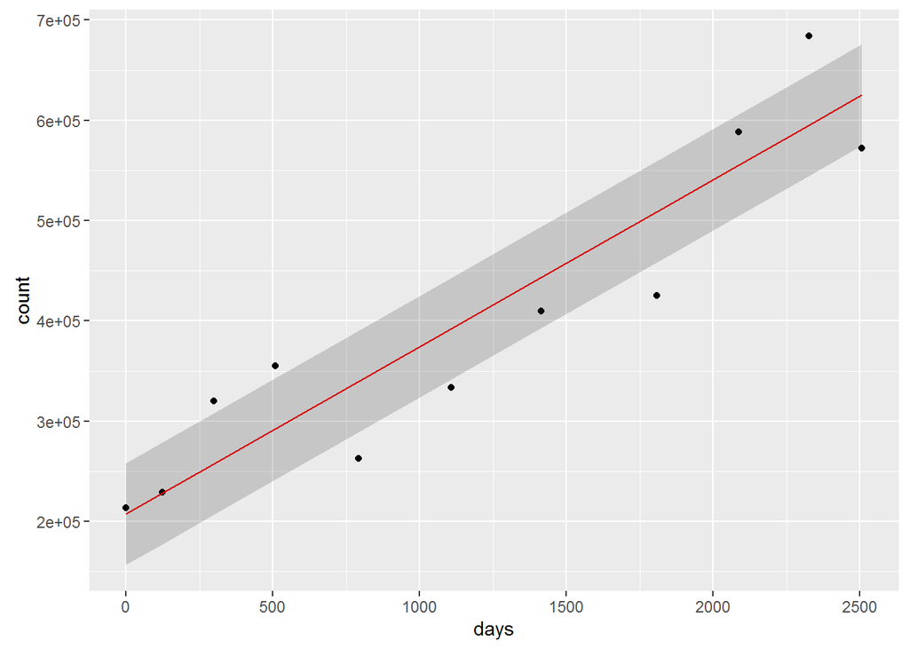

The normalized distance(ND)= 1.0595095

KB growth is 1 if ND<1 or KB growth is 0 if ND>=1

KB growth=0

### Class foaf Person

[http://xmlns.com/foaf/0.1/Person]

Input: Set file location such as -

```r
location<- "/ExperimentalData/DBpedia/"
```

#### Persistency

|  | version | Release | count | class |
| --- | --- | --- | --- | --- |
| 100 | 3.3 | 2009-05-20 | 29498 | foaf-person |
| 101 | 3.4 | 2009-09-20 | 30860 | foaf-person |
| 102 | 3.5 | 2010-03-16 | 48692 | foaf-person |
| 103 | 3.6 | 2010-10-11 | 296595 | foaf-person |
| 104 | 3.7 | 2011-07-22 | 825566 | foaf-person |
| 105 | 3.8 | 2012-06-01 | 1266984 | foaf-person |
| 106 | 3.9 | 2013-04-03 | 1555597 | foaf-person |
| 107 | 2014 | 2014-05-02 | 1650315 | foaf-person |
| 108 | 2015-04 | 2015-02-05 | 2137101 | foaf-person |
| 109 | 2015-10 | 2015-10-02 | 1840598 | foaf-person |
| 110 | 2016-04 | 2016-04-01 | 2703493 | foaf-person |

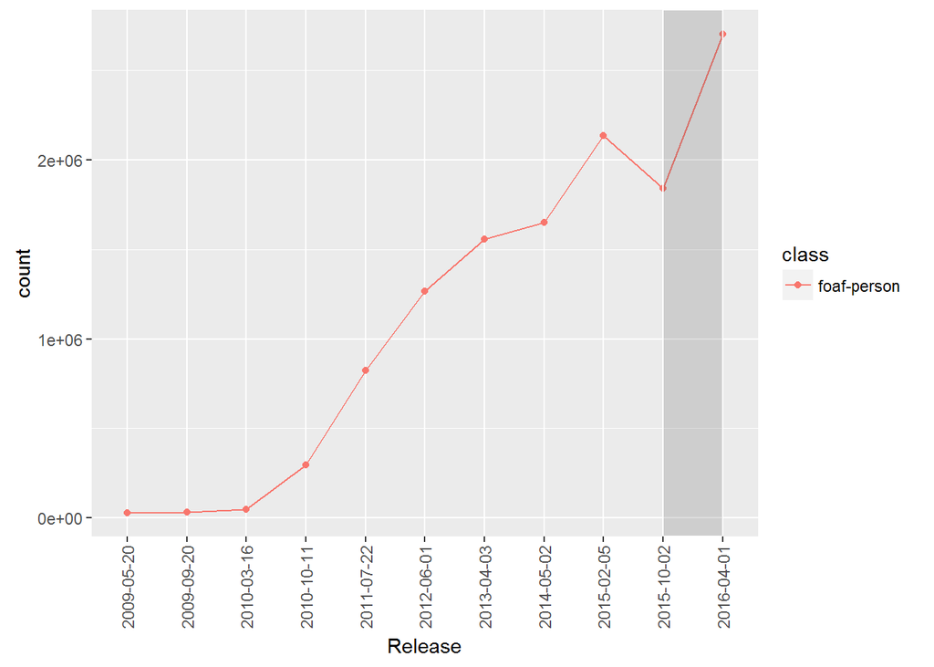

#### Historical Persitency

Historical Persistency Measure Result: Total no. of class = 10 and No. of persistency=1. HistPersistencyMeasure= 88.8888889 %

Releases with persistency values:

|  | version | Release | count | class | Persistency |
| --- | --- | --- | --- | --- | --- |
| 100 | 3.3 | 2009-05-20 | 29498 | foaf-person | 1 |
| 101 | 3.4 | 2009-09-20 | 30860 | foaf-person | 1 |
| 102 | 3.5 | 2010-03-16 | 48692 | foaf-person | 1 |
| 103 | 3.6 | 2010-10-11 | 296595 | foaf-person | 1 |
| 104 | 3.7 | 2011-07-22 | 825566 | foaf-person | 1 |
| 105 | 3.8 | 2012-06-01 | 1266984 | foaf-person | 1 |
| 106 | 3.9 | 2013-04-03 | 1555597 | foaf-person | 1 |
| 107 | 2014 | 2014-05-02 | 1650315 | foaf-person | 1 |
| 108 | 2015-04 | 2015-02-05 | 2137101 | foaf-person | 1 |
| 109 | 2015-10 | 2015-10-02 | 1840598 | foaf-person | 0 |
| 110 | 2016-04 | 2016-04-01 | 2703493 | foaf-person | 1 |

#### Consistency

No. of inconsistent property = 198

|  | property | v201604 | v201510 | v201502 |
| --- | --- | --- | --- | --- |
| 90 | http://dbpedia.org/ontology/Infrastructure/length | 1 | 1 | 1 |
| 143 | http://dbpedia.org/ontology/Work/runtime | 8 | 11 | 8 |
| 150 | http://dbpedia.org/ontology/added | 7 | 11 | 10 |
| 152 | http://dbpedia.org/ontology/affiliation | 0 | 0 | 4 |
| 159 | http://dbpedia.org/ontology/architect | 1 | 1 | 2 |
| 160 | http://dbpedia.org/ontology/architecturalStyle | 3 | 3 | 4 |
| 161 | http://dbpedia.org/ontology/area | 3 | 6 | 0 |
| 162 | http://dbpedia.org/ontology/areaCode | 0 | 0 | 1 |
| 168 | http://dbpedia.org/ontology/artist | 6 | 7 | 9 |
| 173 | http://dbpedia.org/ontology/author | 6 | 7 | 10 |
| 183 | http://dbpedia.org/ontology/bedCount | 0 | 0 | 1 |
| 184 | http://dbpedia.org/ontology/bibsysId | 1 | 1 | 77 |
| 187 | http://dbpedia.org/ontology/bnfId | 16 | 0 | 0 |
| 194 | http://dbpedia.org/ontology/bpnId | 1 | 2 | 0 |
| 196 | http://dbpedia.org/ontology/broadcastArea | 2 | 2 | 0 |
| 197 | http://dbpedia.org/ontology/broadcastNetwork | 0 | 0 | 1 |
| 198 | http://dbpedia.org/ontology/broadcastStationClass | 1 | 1 | 0 |
| 201 | http://dbpedia.org/ontology/buildingEndDate | 0 | 1 | 1 |
| 202 | http://dbpedia.org/ontology/buildingStartDate | 2 | 2 | 2 |
| 203 | http://dbpedia.org/ontology/buildingStartYear | 1 | 1 | 1 |
| 205 | http://dbpedia.org/ontology/callSign | 42 | 40 | 42 |
| 210 | http://dbpedia.org/ontology/capacity | 2 | 2 | 2 |
| 211 | http://dbpedia.org/ontology/capital | 0 | 2 | 0 |
| 212 | http://dbpedia.org/ontology/careerPoints | 0 | 0 | 1 |
| 215 | http://dbpedia.org/ontology/category | 0 | 1 | 1 |
| 216 | http://dbpedia.org/ontology/causalties | 1 | 1 | 3 |
| 222 | http://dbpedia.org/ontology/chairman | 1 | 1 | 1 |
| 223 | http://dbpedia.org/ontology/chairmanTitle | 1 | 1 | 1 |
| 226 | http://dbpedia.org/ontology/channel | 2 | 2 | 2 |
| 228 | http://dbpedia.org/ontology/cinematography | 2 | 2 | 1 |

[output cut: 168 more lines]

List of Consistent Property over last two version:

| Property | version201604 | version201510 | version201504 |
| --- | --- | --- | --- |
| http://dbpedia.org/ontology/Astronaut/timeInSpace | 419 | 465 | 522 |
| http://dbpedia.org/ontology/Person/height | 148192 | 139445 | 94204 |
| http://dbpedia.org/ontology/Person/weight | 66144 | 67412 | 33103 |
| http://dbpedia.org/ontology/abstract | 1165251 | 1282025 | 1172729 |
| http://dbpedia.org/ontology/academicAdvisor | 1244 | 1144 | 1196 |
| http://dbpedia.org/ontology/activeYears | 239 | 0 | 0 |
| http://dbpedia.org/ontology/activeYearsEndDate | 26483 | 25221 | 55171 |
| http://dbpedia.org/ontology/activeYearsEndYear | 69168 | 67999 | 63073 |
| http://dbpedia.org/ontology/activeYearsStartDate | 32247 | 30598 | 67286 |
| http://dbpedia.org/ontology/activeYearsStartYear | 144133 | 141126 | 131743 |
| http://dbpedia.org/ontology/agency | 749 | 0 | 0 |
| http://dbpedia.org/ontology/alias | 98318 | 130973 | 127035 |
| http://dbpedia.org/ontology/allegiance | 19739 | 19406 | 20040 |
| http://dbpedia.org/ontology/almaMater | 121707 | 114136 | 89320 |
| http://dbpedia.org/ontology/appointer | 1588 | 1546 | 1345 |
| http://dbpedia.org/ontology/associate | 2813 | 2567 | 1346 |
| http://dbpedia.org/ontology/associatedAct | 161 | 154 | 183 |
| http://dbpedia.org/ontology/associatedBand | 84951 | 82690 | 85294 |
| http://dbpedia.org/ontology/associatedMusicalArtist | 84951 | 82690 | 85294 |
| http://dbpedia.org/ontology/award | 83685 | 79673 | 93513 |
| http://dbpedia.org/ontology/background | 47511 | 46470 | 44074 |
| http://dbpedia.org/ontology/bandMember | 104 | 157 | 188 |
| http://dbpedia.org/ontology/battingSide | 664 | 643 | 18815 |
| http://dbpedia.org/ontology/battle | 75103 | 72938 | 77774 |
| http://dbpedia.org/ontology/beatifiedBy | 723 | 687 | 626 |
| http://dbpedia.org/ontology/beatifiedDate | 670 | 636 | 520 |
| http://dbpedia.org/ontology/beatifiedPlace | 723 | 654 | 441 |
| http://dbpedia.org/ontology/bestFinish | 337 | 319 | 211 |
| http://dbpedia.org/ontology/billed | 2115 | 1997 | 2199 |
| http://dbpedia.org/ontology/birthDate | 988174 | 1101002 | 1045550 |

[output cut: 208 more lines]

#### Completeness

Total no. of property =436 No. of Consistent Property = 238 No. of incomplete property = 50

Percentage of completeness= 78.9915966 %

List of inincomplete property:

| property | Version201604 | Version201510 | NormFreqDiff |
| --- | --- | --- | --- |
| http://dbpedia.org/ontology/Astronaut/timeInSpace | 0.0001881 | 0.0002088 | -0.0000207 |
| http://dbpedia.org/ontology/Person/weight | 0.0297001 | 0.0302694 | -0.0005694 |
| http://dbpedia.org/ontology/abstract | 0.5232230 | 0.5756570 | -0.0524341 |
| http://dbpedia.org/ontology/alias | 0.0441469 | 0.0588097 | -0.0146628 |
| http://dbpedia.org/ontology/bandMember | 0.0000467 | 0.0000705 | -0.0000238 |
| http://dbpedia.org/ontology/birthDate | 0.4437115 | 0.4943738 | -0.0506622 |
| http://dbpedia.org/ontology/birthPlace | 0.5104478 | 0.5652217 | -0.0547739 |
| http://dbpedia.org/ontology/birthYear | 0.3647084 | 0.4705541 | -0.1058456 |
| http://dbpedia.org/ontology/bnfId | 0.0000000 | 0.0000974 | -0.0000974 |
| http://dbpedia.org/ontology/championships | 0.0003516 | 0.0003543 | -0.0000027 |
| http://dbpedia.org/ontology/coachedTeam | 0.0001006 | 0.0001091 | -0.0000085 |
| http://dbpedia.org/ontology/deathDate | 0.1887759 | 0.2235378 | -0.0347619 |
| http://dbpedia.org/ontology/deathPlace | 0.1364900 | 0.1569825 | -0.0204925 |
| http://dbpedia.org/ontology/deathYear | 0.1641417 | 0.2180813 | -0.0539396 |
| http://dbpedia.org/ontology/debutTeam | 0.0118865 | 0.0125798 | -0.0006933 |
| http://dbpedia.org/ontology/fastestLap | 0.0003408 | 0.0003435 | -0.0000027 |
| http://dbpedia.org/ontology/firstRace | 0.0003538 | 0.0003574 | -0.0000036 |
| http://dbpedia.org/ontology/hallOfFame | 0.0001316 | 0.0001320 | -0.0000004 |
| http://dbpedia.org/ontology/hometown | 0.0175056 | 0.0176412 | -0.0001356 |
| http://dbpedia.org/ontology/imdbId | 0.0130373 | 0.0143862 | -0.0013489 |
| http://dbpedia.org/ontology/instrument | 0.0212859 | 0.0215270 | -0.0002411 |
| http://dbpedia.org/ontology/lastRace | 0.0003453 | 0.0003489 | -0.0000036 |
| http://dbpedia.org/ontology/lccnId | 0.0000647 | 0.0001006 | -0.0000359 |
| http://dbpedia.org/ontology/location | 0.0001769 | 0.0001832 | -0.0000063 |
| http://dbpedia.org/ontology/mission | 0.0005263 | 0.0005851 | -0.0000588 |
| http://dbpedia.org/ontology/mythology | 0.0003498 | 0.0003511 | -0.0000013 |
| http://dbpedia.org/ontology/numberOfFilms | 0.0004001 | 0.0004171 | -0.0000171 |
| http://dbpedia.org/ontology/opponent | 0.0001280 | 0.0001298 | -0.0000018 |
| http://dbpedia.org/ontology/parent | 0.0127621 | 0.0128223 | -0.0000602 |
| http://dbpedia.org/ontology/podiums | 0.0003417 | 0.0003448 | -0.0000031 |
| http://dbpedia.org/ontology/poles | 0.0003399 | 0.0003426 | -0.0000027 |
| http://dbpedia.org/ontology/races | 0.0003448 | 0.0003480 | -0.0000031 |
| http://dbpedia.org/ontology/rating | 0.0000880 | 0.0000961 | -0.0000081 |
| http://dbpedia.org/ontology/soundRecording | 0.0015985 | 0.0020143 | -0.0004158 |
| http://dbpedia.org/ontology/sport | 0.0010323 | 0.0010336 | -0.0000013 |
| http://dbpedia.org/ontology/status | 0.0020112 | 0.0020583 | -0.0000471 |
| http://dbpedia.org/ontology/thumbnail | 0.1659283 | 0.1759644 | -0.0100361 |
| http://dbpedia.org/ontology/timeInSpace | 0.0001881 | 0.0002088 | -0.0000207 |
| http://dbpedia.org/ontology/type | 0.0002910 | 0.0002928 | -0.0000018 |
| http://dbpedia.org/ontology/viafId | 0.0005438 | 0.0007889 | -0.0002452 |
| http://dbpedia.org/ontology/weight | 0.0297001 | 0.0302694 | -0.0005694 |
| http://dbpedia.org/ontology/wikiPageDisambiguates | 0.0000795 | 0.0000894 | -0.0000099 |
| http://dbpedia.org/ontology/wikiPageExternalLink | 0.7868297 | 0.8740970 | -0.0872674 |
| http://dbpedia.org/ontology/wikiPageID | 0.5347992 | 0.5766821 | -0.0418829 |
| http://dbpedia.org/ontology/wikiPageLength | 0.5347992 | 0.5766821 | -0.0418829 |
| http://dbpedia.org/ontology/wikiPageOutDegree | 0.5347992 | 0.5766821 | -0.0418829 |
| http://dbpedia.org/ontology/wikiPageRedirects | 0.0000606 | 0.0000799 | -0.0000193 |
| http://dbpedia.org/ontology/wikiPageRevisionID | 0.5347992 | 0.5766821 | -0.0418829 |
| http://dbpedia.org/ontology/wikiPageWikiLink | 17.9184500 | 21.6471749 | -3.7287249 |
| http://dbpedia.org/ontology/wikiPageWikiLinkText | 0.9916644 | 1.2086909 | -0.2170265 |

#### KB growth

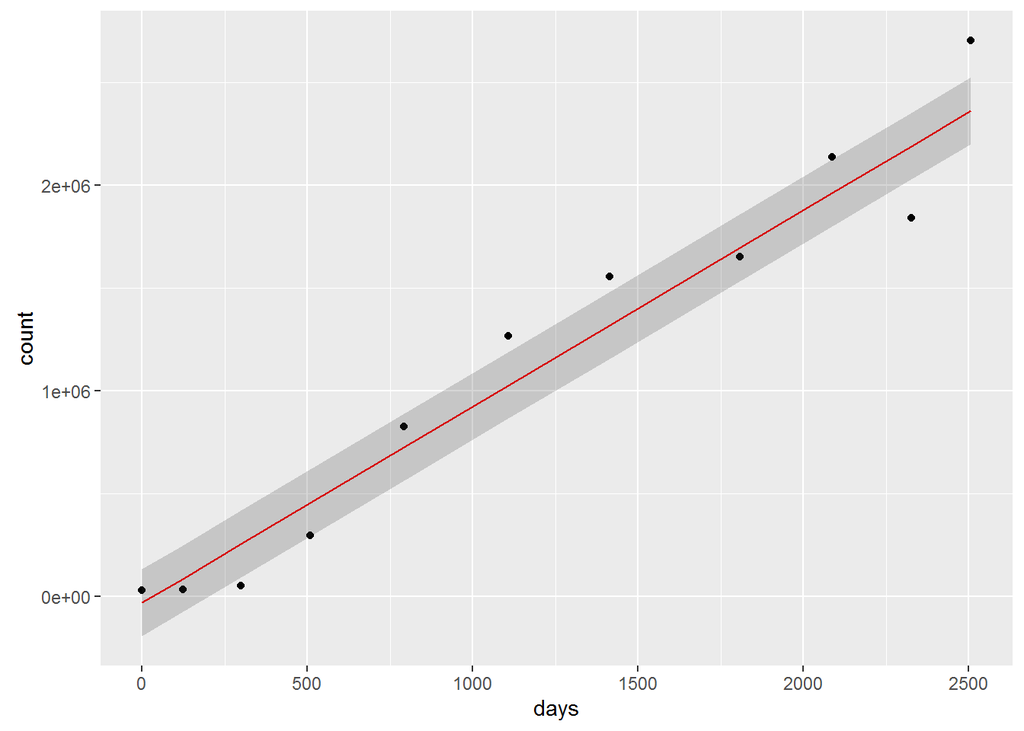

The normalized distance(ND)= 2.0835572

KB growth condition is 1 if ND<1 or KB growth is 0 if ND>=1

KB growth=0